# ANCOVA in Reading Words (1 Min) (Reading Words (1 Min))

Geiser C. Challco geiser@alumni.usp.br

- Setting Initial Variables
- Descriptive Statistics of Initial Data
- ANCOVA and Pairwise for one factor: **grupo**
  - Without remove non-normal data
  - Computing ANCOVA and PairWise After removing non-normal data (OK)
    - Plots for ancova
    - Checking linearity assumption
    - Checking normality and homogeneity
- ANCOVA and Pairwise for two factors **grupo:genero**
  - Without remove non-normal data
  - Computing ANCOVA and PairWise After removing non-normal data (OK)
    - Plots for ancova
    - Checking linearity assumption
    - Checking normality and homogeneity
- ANCOVA and Pairwise for two factors **grupo:zona.participante**
  - Without remove non-normal data
  - Computing ANCOVA and PairWise After removing non-normal data (OK)
    - Plots for ancova
    - Checking linearity assumption
    - Checking normality and homogeneity
- ANCOVA and Pairwise for two factors **grupo:zona.escola**
  - Without remove non-normal data
  - Computing ANCOVA and PairWise After removing non-normal data (OK)
    - Plots for ancova
    - Checking linearity assumption
    - Checking normality and homogeneity
- ANCOVA and Pairwise for two factors **grupo:palavras.lidas.quintile**
  - Without remove non-normal data
  - Computing ANCOVA and PairWise After removing non-normal data (OK)
    - Plots for ancova
    - Checking linearity assumption
    - Checking normality and homogeneity
- Summary of Results
  - Descriptive Statistics
  - ANCOVA Table Comparison
  - PairWise Table Comparison
  - EMMS Table Comparison

**NOTE**:

- Teste ANCOVA para determinar se houve diferenças significativas no Reading Words (1 Min) (medido usando pre- e pos-testes).
- ANCOVA test to determine whether there were significant differences in Reading Words (1 Min) (measured using pre- and post-tests).

# Setting Initial Variables

```r
dv = "palavras.lidas"
dv.pos = "palavras.lidas.pos"
dv.pre = "palavras.lidas.pre"

fatores2 <- c("genero","zona.participante","zona.escola","palavras.lidas.quintile")
lfatores2 <- as.list(fatores2)
names(lfatores2) <- fatores2

fatores1 <- c("grupo", fatores2)
lfatores1 <- as.list(fatores1)
names(lfatores1) <- fatores1

lfatores <- c(lfatores1)

color <- list()
color[["prepost"]] = c("#ffee65","#f28e2B")
color[["grupo"]] = c("#bcbd22","#008000")
color[["genero"]] = c("#FF007F","#4D4DFF")
color[["zona.escola"]] = c("#AA00FF","#00CCCC")
color[["zona.participante"]] = c("#AA00FF","#00CCCC")

level <- list()
level[["grupo"]] = c("Controle","Experimental")
level[["genero"]] = c("F","M")
level[["zona.escola"]] = c("Rural","Urbana")
level[["zona.participante"]] = c("Rural","Urbana")

# ..

ymin <- 0
ymax <- 0

ymin.ci <- 0
ymax.ci <- 0


color[["grupo:genero"]] = c(
  "Controle:F"="#ff99cb", "Controle:M"="#b7b7ff",
  "Experimental:F"="#FF007F", "Experimental:M"="#4D4DFF",
  "Controle.F"="#ff99cb", "Controle.M"="#b7b7ff",
  "Experimental.F"="#FF007F", "Experimental.M"="#4D4DFF"
)
color[["grupo:zona.escola"]] = c(
  "Controle:Rural"="#b2efef","Controle:Urbana"="#e5b2ff",
  "Experimental:Rural"="#00CCCC", "Experimental:Urbana"="#AA00FF",
  "Controle.Rural"="#b2efef","Controle.Urbana"="#e5b2ff",
  "Experimental.Rural"="#00CCCC", "Experimental.Urbana"="#AA00FF"
)
color[["grupo:zona.participante"]] = c(
  "Controle:Rural"="#b2efef","Controle:Urbana"="#e5b2ff",
  "Experimental:Rural"="#00CCCC", "Experimental:Urbana"="#AA00FF",
  "Controle.Rural"="#b2efef","Controle.Urbana"="#e5b2ff",
  "Experimental.Rural"="#00CCCC", "Experimental.Urbana"="#AA00FF"
)

for (coln in c(
  "palavras.lidas","score.compreensao","tri.compreensao",
  "score.vocab","tri.vocab",
  "score.vocab.ensinado","tri.vocab.ensinado","score.vocab.nao.ensinado","tri.vocab.nao.ensinado",
  "score.CLPP","tri.CLPP","score.CR","tri.CR",
  "score.CI","tri.CI","score.TV","tri.TV","score.TF","tri.TF","score.TO","tri.TO")) {
  color[[paste0(coln,".quintile")]] = c("#BF0040","#FF0000","#800080","#0000FF","#4000BF")
  level[[paste0(coln,".quintile")]] = c("1st quintile","2nd quintile","3rd quintile","4th quintile","5th quintile")
  color[[paste0("grupo:",coln,".quintile")]] = c(
    "Experimental.1st quintile"="#BF0040", "Controle.1st quintile"="#d8668c",
    "Experimental.2nd quintile"="#FF0000", "Controle.2nd quintile"="#ff7f7f",
    "Experimental.3rd quintile"="#8fce00", "Controle.3rd quintile"="#ddf0b2",
    "Experimental.4th quintile"="#0000FF", "Controle.4th quintile"="#b2b2ff",
    "Experimental.5th quintile"="#4000BF", "Controle.5th quintile"="#b299e5",

    "Experimental:1st quintile"="#BF0040", "Controle:1st quintile"="#d8668c",
    "Experimental:2nd quintile"="#FF0000", "Controle:2nd quintile"="#ff7f7f",
    "Experimental:3rd quintile"="#8fce00", "Controle:3rd quintile"="#ddf0b2",
    "Experimental:4th quintile"="#0000FF", "Controle:4th quintile"="#b2b2ff",
    "Experimental:5th quintile"="#4000BF", "Controle:5th quintile"="#b299e5")
}


gdat <- read_excel("../data/data.xlsx", sheet = "triagem.wg.wo.st")



dat <- gdat
dat$grupo <- factor(dat[["grupo"]], level[["grupo"]])
for (coln in c(names(lfatores))) {
  dat[[coln]] <- factor(dat[[coln]], level[[coln]][level[[coln]] %in% unique(dat[[coln]])])
}
dat <- dat[which(!is.na(dat[[dv.pre]]) & !is.na(dat[[dv.pos]])),]
dat <- dat[,c("id",names(lfatores),dv.pre,dv.pos)]

dat.long <- rbind(dat, dat)
dat.long$time <- c(rep("pre", nrow(dat)), rep("pos", nrow(dat)))
dat.long$time <- factor(dat.long$time, c("pre","pos"))
dat.long[[dv]] <- c(dat[[dv.pre]], dat[[dv.pos]])


for (f in c("grupo", names(lfatores))) {
  if (is.null(color[[f]]) && length(unique(dat[[f]])) > 0)
      color[[f]] <- distinctColorPalette(length(unique(dat[[f]])))
}
for (f in c(fatores2)) {
  if (is.null(color[[paste0("grupo:",f)]]) && length(unique(dat[[f]])) > 0)
    color[[paste0("grupo:",f)]] <- distinctColorPalette(length(unique(dat[["grupo"]]))*length(unique(dat[[f]])))
}

ldat <- list()
laov <- list()
lpwc <- list()
lemms <- list()
```

# Descriptive Statistics of Initial Data

```r
df <- get.descriptives(dat, c(dv.pre, dv.pos), c("grupo"),
                       include.global = T, symmetry.test = T, normality.test = F)
df <- plyr::rbind.fill(
  df, do.call(plyr::rbind.fill, lapply(lfatores2, FUN = function(f) {
    if (nrow(dat) > 0 && sum(!is.na(unique(dat[[f]]))) > 1)
      get.descriptives(dat, c(dv.pre,dv.pos), c("grupo", f),
                       symmetry.test = T, normality.test = F)
    }))
)
df <- df[,c(fatores1[fatores1 %in% colnames(df)],"variable",
            colnames(df)[!colnames(df) %in% c(fatores1,"variable")])]
```

| grupo | genero | zona.participante | zona.escola | palavras.lidas.quintile | variable | n | mean | median | min | max | sd | se | ci | iqr | symmetry | skewness | kurtosis |
| --- | --- | --- | --- | --- | --- | --- | --- | --- | --- | --- | --- | --- | --- | --- | --- | --- | --- |
| Controle |  |  |  |  | palavras.lidas.pre | 137 | 122.562 | 98.0 | 1 | 398 | 80.931 | 6.914 | 13.674 | 113.00 | NO | 0.915 | 0.315 |
| Experimental |  |  |  |  | palavras.lidas.pre | 104 | 127.077 | 94.0 | 13 | 373 | 85.781 | 8.412 | 16.682 | 85.25 | NO | 1.164 | 0.386 |
|  |  |  |  |  | palavras.lidas.pre | 241 | 124.510 | 94.0 | 1 | 398 | 82.913 | 5.341 | 10.521 | 101.00 | NO | 1.045 | 0.412 |
| Controle |  |  |  |  | palavras.lidas.pos | 137 | 114.993 | 102.0 | 8 | 430 | 60.072 | 5.132 | 10.149 | 63.00 | NO | 1.755 | 6.056 |
| Experimental |  |  |  |  | palavras.lidas.pos | 104 | 142.096 | 137.0 | 33 | 430 | 70.439 | 6.907 | 13.699 | 77.50 | NO | 1.557 | 3.594 |
|  |  |  |  |  | palavras.lidas.pos | 241 | 126.689 | 116.0 | 8 | 430 | 65.994 | 4.251 | 8.374 | 70.00 | NO | 1.664 | 4.706 |
| Controle | F |  |  |  | palavras.lidas.pre | 73 | 123.466 | 94.0 | 20 | 319 | 82.731 | 9.683 | 19.303 | 119.00 | NO | 0.860 | -0.240 |
| Controle | M |  |  |  | palavras.lidas.pre | 64 | 121.531 | 100.0 | 1 | 398 | 79.468 | 9.934 | 19.851 | 100.00 | NO | 0.960 | 0.933 |
| Experimental | F |  |  |  | palavras.lidas.pre | 50 | 139.780 | 117.5 | 13 | 373 | 87.988 | 12.443 | 25.006 | 98.50 | NO | 0.966 | -0.006 |
| Experimental | M |  |  |  | palavras.lidas.pre | 54 | 115.315 | 85.0 | 27 | 338 | 82.761 | 11.262 | 22.589 | 68.50 | NO | 1.368 | 0.838 |
| Controle | F |  |  |  | palavras.lidas.pos | 73 | 115.973 | 100.0 | 13 | 262 | 47.235 | 5.528 | 11.021 | 55.00 | NO | 0.850 | 0.718 |
| Controle | M |  |  |  | palavras.lidas.pos | 64 | 113.875 | 104.5 | 8 | 430 | 72.372 | 9.047 | 18.078 | 71.00 | NO | 1.905 | 5.533 |
| Experimental | F |  |  |  | palavras.lidas.pos | 50 | 162.560 | 145.5 | 57 | 430 | 75.532 | 10.682 | 21.466 | 96.00 | NO | 1.187 | 1.563 |
| Experimental | M |  |  |  | palavras.lidas.pos | 54 | 123.148 | 110.0 | 33 | 419 | 60.059 | 8.173 | 16.393 | 54.75 | NO | 2.108 | 8.534 |
| Controle |  | Rural |  |  | palavras.lidas.pre | 47 | 124.404 | 102.0 | 29 | 319 | 79.055 | 11.531 | 23.211 | 105.50 | NO | 0.858 | -0.210 |
| Controle |  | Urbana |  |  | palavras.lidas.pre | 61 | 132.492 | 107.0 | 2 | 398 | 88.066 | 11.276 | 22.555 | 123.00 | NO | 0.857 | 0.082 |
| Controle |  |  |  |  | palavras.lidas.pre | 29 | 98.690 | 85.0 | 1 | 256 | 64.159 | 11.914 | 24.405 | 99.00 | NO | 0.520 | -0.591 |
| Experimental |  | Rural |  |  | palavras.lidas.pre | 43 | 124.814 | 91.0 | 27 | 341 | 91.589 | 13.967 | 28.187 | 84.00 | NO | 1.134 | -0.040 |
| Experimental |  | Urbana |  |  | palavras.lidas.pre | 36 | 146.083 | 129.0 | 29 | 373 | 92.586 | 15.431 | 31.327 | 111.50 | NO | 0.910 | -0.363 |
| Experimental |  |  |  |  | palavras.lidas.pre | 25 | 103.600 | 92.0 | 13 | 262 | 57.214 | 11.443 | 23.617 | 63.00 | NO | 0.829 | 0.464 |
| Controle |  | Rural |  |  | palavras.lidas.pos | 47 | 116.553 | 112.0 | 18 | 228 | 48.159 | 7.025 | 14.140 | 53.00 | YES | 0.223 | -0.358 |
| Controle |  | Urbana |  |  | palavras.lidas.pos | 61 | 112.098 | 94.0 | 8 | 430 | 72.869 | 9.330 | 18.662 | 63.00 | NO | 2.178 | 6.116 |
| Controle |  |  |  |  | palavras.lidas.pos | 29 | 118.552 | 119.0 | 33 | 223 | 47.996 | 8.913 | 18.257 | 64.00 | YES | 0.349 | -0.675 |
| Experimental |  | Rural |  |  | palavras.lidas.pos | 43 | 118.837 | 119.0 | 33 | 270 | 48.009 | 7.321 | 14.775 | 57.50 | NO | 0.671 | 0.781 |
| Experimental |  | Urbana |  |  | palavras.lidas.pos | 36 | 161.417 | 142.5 | 39 | 430 | 81.056 | 13.509 | 27.425 | 96.50 | NO | 1.226 | 1.638 |
| Experimental |  |  |  |  | palavras.lidas.pos | 25 | 154.280 | 146.0 | 57 | 419 | 77.429 | 15.486 | 31.961 | 77.00 | NO | 1.576 | 3.037 |
| Controle |  |  | Rural |  | palavras.lidas.pre | 52 | 162.173 | 168.5 | 5 | 398 | 94.788 | 13.145 | 26.389 | 135.25 | YES | 0.356 | -0.779 |
| Controle |  |  | Urbana |  | palavras.lidas.pre | 85 | 98.329 | 81.0 | 1 | 293 | 59.867 | 6.493 | 12.913 | 74.00 | NO | 0.884 | 0.383 |
| Experimental |  |  | Rural |  | palavras.lidas.pre | 36 | 143.750 | 117.5 | 13 | 341 | 103.202 | 17.200 | 34.918 | 136.00 | NO | 0.598 | -1.081 |
| Experimental |  |  | Urbana |  | palavras.lidas.pre | 68 | 118.250 | 91.0 | 27 | 373 | 74.296 | 9.010 | 17.984 | 71.00 | NO | 1.571 | 2.020 |
| Controle |  |  | Rural |  | palavras.lidas.pos | 52 | 103.827 | 102.5 | 8 | 211 | 45.228 | 6.272 | 12.592 | 63.75 | YES | 0.161 | -0.376 |
| Controle |  |  | Urbana |  | palavras.lidas.pos | 85 | 121.824 | 102.0 | 13 | 430 | 66.904 | 7.257 | 14.431 | 61.00 | NO | 1.854 | 5.306 |
| Experimental |  |  | Rural |  | palavras.lidas.pos | 36 | 104.000 | 94.5 | 33 | 178 | 34.420 | 5.737 | 11.646 | 39.00 | YES | 0.320 | -0.587 |
| Experimental |  |  | Urbana |  | palavras.lidas.pos | 68 | 162.265 | 145.0 | 33 | 430 | 76.264 | 9.248 | 18.460 | 80.50 | NO | 1.284 | 2.352 |
| Controle |  |  |  | 1st quintile | palavras.lidas.pre | 26 | 32.154 | 34.0 | 1 | 47 | 12.746 | 2.500 | 5.148 | 11.00 | NO | -1.265 | 0.645 |
| Controle |  |  |  | 2nd quintile | palavras.lidas.pre | 34 | 71.235 | 70.0 | 50 | 87 | 9.049 | 1.552 | 3.157 | 13.75 | YES | -0.204 | -0.761 |
| Controle |  |  |  | 3rd quintile | palavras.lidas.pre | 28 | 109.536 | 108.5 | 88 | 135 | 14.980 | 2.831 | 5.809 | 29.00 | YES | 0.111 | -1.419 |
| Controle |  |  |  | 4th quintile | palavras.lidas.pre | 33 | 179.485 | 180.0 | 141 | 219 | 22.483 | 3.914 | 7.972 | 39.00 | YES | -0.082 | -1.183 |
| Controle |  |  |  | 5th quintile | palavras.lidas.pre | 16 | 283.938 | 291.5 | 220 | 398 | 45.717 | 11.429 | 24.361 | 58.50 | NO | 0.609 | 0.021 |
| Experimental |  |  |  | 1st quintile | palavras.lidas.pre | 11 | 33.182 | 33.0 | 13 | 45 | 8.460 | 2.551 | 5.683 | 7.00 | NO | -0.922 | 0.413 |
| Experimental |  |  |  | 2nd quintile | palavras.lidas.pre | 35 | 70.086 | 70.0 | 49 | 86 | 11.668 | 1.972 | 4.008 | 16.50 | YES | -0.314 | -1.006 |
| Experimental |  |  |  | 3rd quintile | palavras.lidas.pre | 24 | 109.875 | 107.0 | 88 | 135 | 17.384 | 3.548 | 7.341 | 32.75 | YES | 0.157 | -1.769 |
| Experimental |  |  |  | 4th quintile | palavras.lidas.pre | 18 | 166.389 | 165.0 | 141 | 219 | 25.964 | 6.120 | 12.912 | 36.25 | NO | 0.586 | -1.082 |
| Experimental |  |  |  | 5th quintile | palavras.lidas.pre | 16 | 297.875 | 299.0 | 221 | 373 | 38.145 | 9.536 | 20.326 | 58.25 | YES | -0.033 | -0.639 |
| Controle |  |  |  | 1st quintile | palavras.lidas.pos | 26 | 85.615 | 85.0 | 13 | 228 | 47.569 | 9.329 | 19.214 | 53.25 | NO | 0.890 | 0.986 |
| Controle |  |  |  | 2nd quintile | palavras.lidas.pos | 34 | 105.235 | 94.0 | 40 | 363 | 56.675 | 9.720 | 19.775 | 41.00 | NO | 2.830 | 10.002 |
| Controle |  |  |  | 3rd quintile | palavras.lidas.pos | 28 | 140.607 | 141.0 | 33 | 252 | 49.480 | 9.351 | 19.186 | 57.75 | YES | 0.218 | -0.377 |
| Controle |  |  |  | 4th quintile | palavras.lidas.pos | 33 | 125.970 | 123.0 | 8 | 430 | 70.882 | 12.339 | 25.134 | 67.00 | NO | 2.188 | 7.781 |
| Controle |  |  |  | 5th quintile | palavras.lidas.pos | 16 | 116.000 | 97.5 | 40 | 262 | 59.602 | 14.901 | 31.760 | 58.00 | NO | 1.003 | 0.162 |
| Experimental |  |  |  | 1st quintile | palavras.lidas.pos | 11 | 67.091 | 61.0 | 33 | 127 | 29.256 | 8.821 | 19.654 | 40.50 | NO | 0.530 | -0.871 |
| Experimental |  |  |  | 2nd quintile | palavras.lidas.pos | 35 | 141.771 | 132.0 | 70 | 335 | 63.222 | 10.687 | 21.718 | 62.00 | NO | 1.380 | 1.335 |
| Experimental |  |  |  | 3rd quintile | palavras.lidas.pos | 24 | 155.542 | 147.0 | 75 | 270 | 46.335 | 9.458 | 19.566 | 44.25 | NO | 0.631 | 0.583 |
| Experimental |  |  |  | 4th quintile | palavras.lidas.pos | 18 | 137.444 | 133.5 | 70 | 218 | 50.160 | 11.823 | 24.944 | 79.50 | YES | 0.215 | -1.567 |
| Experimental |  |  |  | 5th quintile | palavras.lidas.pos | 16 | 179.438 | 141.0 | 72 | 430 | 111.211 | 27.803 | 59.260 | 117.00 | NO | 1.176 | 0.156 |

# ANCOVA and Pairwise for one factor: **grupo**

## Without remove non-normal data

```r
pdat = remove_group_data(dat[!is.na(dat[["grupo"]]),], "palavras.lidas.pos", "grupo")

pdat.long <- rbind(pdat[,c("id","grupo")], pdat[,c("id","grupo")])
pdat.long[["time"]] <- c(rep("pre", nrow(pdat)), rep("pos", nrow(pdat)))
pdat.long[["time"]] <- factor(pdat.long[["time"]], c("pre","pos"))
pdat.long[["palavras.lidas"]] <- c(pdat[["palavras.lidas.pre"]], pdat[["palavras.lidas.pos"]])

aov = anova_test(pdat, palavras.lidas.pos ~ palavras.lidas.pre + grupo)
laov[["grupo"]] <- get_anova_table(aov)
```

```r
pwc <- emmeans_test(pdat, palavras.lidas.pos ~ grupo, covariate = palavras.lidas.pre,
                    p.adjust.method = "bonferroni")
```

```r
pwc.long <- emmeans_test(dplyr::group_by_at(pdat.long, "grupo"),
                          palavras.lidas ~ time,
                          p.adjust.method = "bonferroni")
lpwc[["grupo"]] <- plyr::rbind.fill(pwc, pwc.long)
```

```r
ds <- get.descriptives(pdat, "palavras.lidas.pos", "grupo", covar = "palavras.lidas.pre")
ds <- merge(ds[ds$variable != "palavras.lidas.pre",],
            ds[ds$variable == "palavras.lidas.pre", !colnames(ds) %in% c("variable")],
            by = "grupo", all.x = T, suffixes = c("", ".palavras.lidas.pre"))
ds <- merge(get_emmeans(pwc), ds, by = "grupo", suffixes = c(".emms", ""))
ds <- ds[,c("grupo","n","mean.palavras.lidas.pre","se.palavras.lidas.pre","mean","se",
            "emmean","se.emms","conf.low","conf.high")]

colnames(ds) <- c("grupo", "N", paste0(c("M","SE")," (pre)"),
                  paste0(c("M","SE"), " (unadj)"),
                  paste0(c("M", "SE"), " (adj)"), "conf.low", "conf.high")

lemms[["grupo"]] <- ds
```

## Computing ANCOVA and PairWise After removing non-normal data (OK)

```r
wdat = pdat

res = residuals(lm(palavras.lidas.pos ~ palavras.lidas.pre + grupo, data = wdat))
non.normal = getNonNormal(res, wdat$id, plimit = 0.05)

wdat = wdat[!wdat$id %in% non.normal,]

wdat.long <- rbind(wdat[,c("id","grupo")], wdat[,c("id","grupo")])
wdat.long[["time"]] <- c(rep("pre", nrow(wdat)), rep("pos", nrow(wdat)))
wdat.long[["time"]] <- factor(wdat.long[["time"]], c("pre","pos"))
wdat.long[["palavras.lidas"]] <- c(wdat[["palavras.lidas.pre"]], wdat[["palavras.lidas.pos"]])

ldat[["grupo"]] = wdat

(non.normal)
```

```
##  [1] "P96"  "P171" "P24"  "P172" "P68"  "P40"  "P229" "P37"  "P318" "P180" "P283" "P16"  "P90"
## [14] "P94"  "P353"
```

```r
aov = anova_test(wdat, palavras.lidas.pos ~ palavras.lidas.pre + grupo)
laov[["grupo"]] <- merge(get_anova_table(aov), laov[["grupo"]],
                            by="Effect", suffixes = c("","'"))

(df = get_anova_table(aov))
```

```
## ANOVA Table (type II tests)
##
##               Effect DFn DFd      F        p p<.05   ges
## 1 palavras.lidas.pre   1 223 13.569 0.000289     * 0.057
## 2              grupo   1 223 10.571 0.001000     * 0.045
```

| Effect | DFn | DFd | F | p | p<.05 | ges |
| --- | --- | --- | --- | --- | --- | --- |
| palavras.lidas.pre | 1 | 223 | 13.569 | 0.000 | * | 0.057 |
| grupo | 1 | 223 | 10.571 | 0.001 | * | 0.045 |

```r
pwc <- emmeans_test(wdat, palavras.lidas.pos ~ grupo, covariate = palavras.lidas.pre,
                    p.adjust.method = "bonferroni")
```

| term | .y. | group1 | group2 | df | statistic | p | p.adj | p.adj.signif |
| --- | --- | --- | --- | --- | --- | --- | --- | --- |
| palavras.lidas.pre*grupo | palavras.lidas.pos | Controle | Experimental | 223 | -3.251 | 0.001 | 0.001 | ** |

```r
pwc.long <- emmeans_test(dplyr::group_by_at(wdat.long, "grupo"),
                         palavras.lidas ~ time,
                         p.adjust.method = "bonferroni")
lpwc[["grupo"]] <- merge(plyr::rbind.fill(pwc, pwc.long), lpwc[["grupo"]],
                            by=c("grupo","term",".y.","group1","group2"),
                            suffixes = c("","'"))
```

| grupo | term | .y. | group1 | group2 | df | statistic | p | p.adj | p.adj.signif |
| --- | --- | --- | --- | --- | --- | --- | --- | --- | --- |
| Controle | time | palavras.lidas | pre | pos | 448 | 1.615 | 0.107 | 0.107 | ns |
| Experimental | time | palavras.lidas | pre | pos | 448 | -0.052 | 0.959 | 0.959 | ns |

```r
ds <- get.descriptives(wdat, "palavras.lidas.pos", "grupo", covar = "palavras.lidas.pre")
ds <- merge(ds[ds$variable != "palavras.lidas.pre",],
            ds[ds$variable == "palavras.lidas.pre", !colnames(ds) %in% c("variable")],
            by = "grupo", all.x = T, suffixes = c("", ".palavras.lidas.pre"))
ds <- merge(get_emmeans(pwc), ds, by = "grupo", suffixes = c(".emms", ""))
ds <- ds[,c("grupo","n","mean.palavras.lidas.pre","se.palavras.lidas.pre","mean","se",
            "emmean","se.emms","conf.low","conf.high")]

colnames(ds) <- c("grupo", "N", paste0(c("M","SE")," (pre)"),
                  paste0(c("M","SE"), " (unadj)"),
                  paste0(c("M", "SE"), " (adj)"), "conf.low", "conf.high")

lemms[["grupo"]] <- merge(ds, lemms[["grupo"]], by=c("grupo"), suffixes = c("","'"))
```

| grupo | N | M (pre) | SE (pre) | M (unadj) | SE (unadj) | M (adj) | SE (adj) | conf.low | conf.high |
| --- | --- | --- | --- | --- | --- | --- | --- | --- | --- |
| Controle | 131 | 121.626 | 7.058 | 108.237 | 3.947 | 108.599 | 3.898 | 100.918 | 116.280 |
| Experimental | 95 | 128.147 | 8.848 | 128.653 | 4.794 | 128.153 | 4.578 | 119.133 | 137.174 |

### Plots for ancova

```r
plots <- oneWayAncovaPlots(
  wdat, "palavras.lidas.pos", "grupo", aov, list("grupo"=pwc), addParam = c("mean_ci"),
  font.label.size=10, step.increase=0.05, p.label="p.adj",
  subtitle = which(aov$Effect == "grupo"))
```

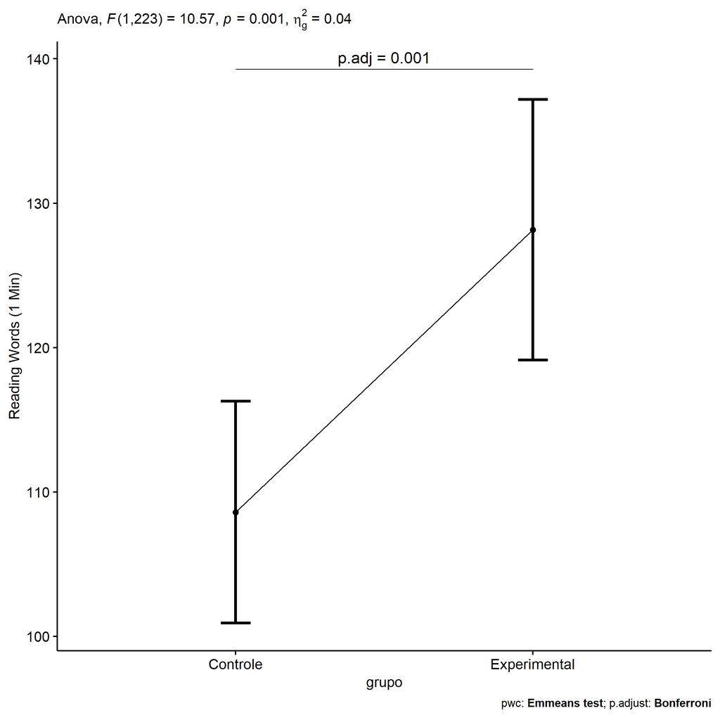

```r
if (!is.null(nrow(plots[["grupo"]]$data)))
  plots[["grupo"]] + ggplot2::ylab("Reading Words (1 Min)") +
  if (ymin.ci < ymax.ci) ggplot2::ylim(ymin.ci, ymax.ci)
```

```r
plots <- oneWayAncovaBoxPlots(
  wdat, "palavras.lidas.pos", "grupo", aov, pwc, covar = "palavras.lidas.pre",
  theme = "classic", color = color[["grupo"]],
  subtitle = which(aov$Effect == "grupo"))
```

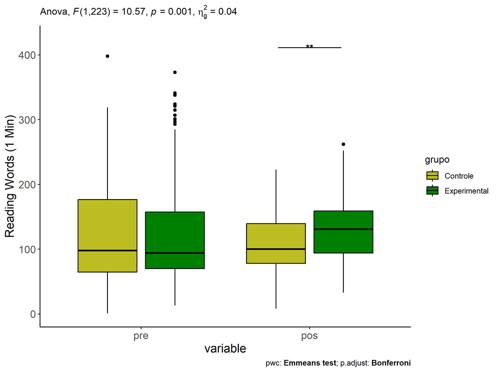

```r
if (length(unique(wdat[["grupo"]])) > 1)
  plots[["grupo"]] + ggplot2::ylab("Reading Words (1 Min)") +
  ggplot2::scale_x_discrete(labels=c('pre', 'pos')) +
  if (ymin < ymax) ggplot2::ylim(ymin, ymax)
```

```r
if (length(unique(wdat.long[["grupo"]])) > 1)
  plots <- oneWayAncovaBoxPlots(
    wdat.long, "palavras.lidas", "grupo", aov, pwc.long,
    pre.post = "time", theme = "classic", color = color$prepost)
```

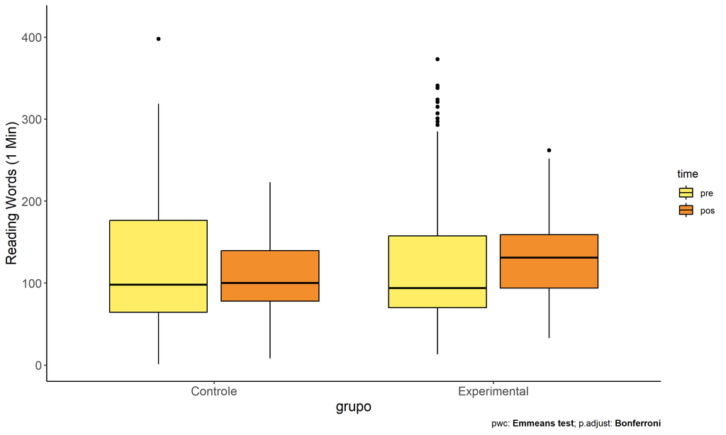

```r
if (length(unique(wdat.long[["grupo"]])) > 1)
  plots[["grupo"]] + ggplot2::ylab("Reading Words (1 Min)") +
  if (ymin < ymax) ggplot2::ylim(ymin, ymax)
```

### Checking linearity assumption

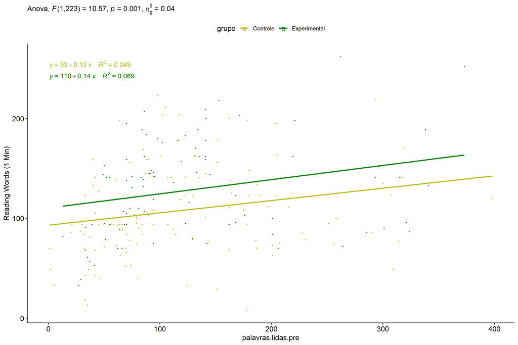

```r
ggscatter(wdat, x = "palavras.lidas.pre", y = "palavras.lidas.pos", size = 0.5,
          color = "grupo", add = "reg.line")+
  stat_regline_equation(
    aes(label =  paste(..eq.label.., ..rr.label.., sep = "~~~~"), color = grupo)
  ) +
  ggplot2::labs(subtitle = rstatix::get_test_label(aov, detailed = T, row = which(aov$Effect == "grupo"))) +
  ggplot2::scale_color_manual(values = color[["grupo"]]) +
  ggplot2::ylab("Reading Words (1 Min)")  +
  if (ymin < ymax) ggplot2::ylim(ymin, ymax)
```

### Checking normality and homogeneity

```r
res <- augment(lm(palavras.lidas.pos ~ palavras.lidas.pre + grupo, data = wdat))
```

```r
shapiro_test(res$.resid)
```

```
## # A tibble: 1 × 3
##   variable   statistic p.value
##   <chr>          <dbl>   <dbl>
## 1 res$.resid     0.988  0.0565
```

```r
levene_test(res, .resid ~ grupo)
```

```
## # A tibble: 1 × 4
##     df1   df2 statistic     p
##   <int> <int>     <dbl> <dbl>
## 1     1   224      1.37 0.243
```

# ANCOVA and Pairwise for two factors **grupo:genero**

## Without remove non-normal data

```r
pdat = remove_group_data(dat[!is.na(dat[["grupo"]]) & !is.na(dat[["genero"]]),],
                         "palavras.lidas.pos", c("grupo","genero"))
pdat = pdat[pdat[["genero"]] %in% do.call(
  intersect, lapply(unique(pdat[["grupo"]]), FUN = function(x) {
    unique(pdat[["genero"]][which(pdat[["grupo"]] == x)])
  })),]
pdat[["grupo"]] = factor(pdat[["grupo"]], level[["grupo"]])
pdat[["genero"]] = factor(
  pdat[["genero"]],
  level[["genero"]][level[["genero"]] %in% unique(pdat[["genero"]])])

pdat.long <- rbind(pdat[,c("id","grupo","genero")], pdat[,c("id","grupo","genero")])
pdat.long[["time"]] <- c(rep("pre", nrow(pdat)), rep("pos", nrow(pdat)))
pdat.long[["time"]] <- factor(pdat.long[["time"]], c("pre","pos"))
pdat.long[["palavras.lidas"]] <- c(pdat[["palavras.lidas.pre"]], pdat[["palavras.lidas.pos"]])

if (length(unique(pdat[["genero"]])) >= 2) {
  aov = anova_test(pdat, palavras.lidas.pos ~ palavras.lidas.pre + grupo*genero)
  laov[["grupo:genero"]] <- get_anova_table(aov)
}
```

```r
if (length(unique(pdat[["genero"]])) >= 2) {
  pwcs <- list()
  pwcs[["genero"]] <- emmeans_test(
    group_by(pdat, grupo), palavras.lidas.pos ~ genero,
    covariate = palavras.lidas.pre, p.adjust.method = "bonferroni")
  pwcs[["grupo"]] <- emmeans_test(
    group_by(pdat, genero), palavras.lidas.pos ~ grupo,
    covariate = palavras.lidas.pre, p.adjust.method = "bonferroni")

  pwc <- plyr::rbind.fill(pwcs[["grupo"]], pwcs[["genero"]])
  pwc <- pwc[,c("grupo","genero", colnames(pwc)[!colnames(pwc) %in% c("grupo","genero")])]
}
```

```r
if (length(unique(pdat[["genero"]])) >= 2) {
  pwc.long <- emmeans_test(dplyr::group_by_at(pdat.long, c("grupo","genero")),
                           palavras.lidas ~ time,
                           p.adjust.method = "bonferroni")
  lpwc[["grupo:genero"]] <- plyr::rbind.fill(pwc, pwc.long)
}
```

```r
if (length(unique(pdat[["genero"]])) >= 2) {
  ds <- get.descriptives(pdat, "palavras.lidas.pos", c("grupo","genero"), covar = "palavras.lidas.pre")
  ds <- merge(ds[ds$variable != "palavras.lidas.pre",],
              ds[ds$variable == "palavras.lidas.pre", !colnames(ds) %in% c("variable")],
              by = c("grupo","genero"), all.x = T, suffixes = c("", ".palavras.lidas.pre"))
  ds <- merge(get_emmeans(pwcs[["grupo"]]), ds,
              by = c("grupo","genero"), suffixes = c(".emms", ""))
  ds <- ds[,c("grupo","genero","n","mean.palavras.lidas.pre","se.palavras.lidas.pre","mean","se",
              "emmean","se.emms","conf.low","conf.high")]

  colnames(ds) <- c("grupo","genero", "N", paste0(c("M","SE")," (pre)"),
                    paste0(c("M","SE"), " (unadj)"),
                    paste0(c("M", "SE"), " (adj)"), "conf.low", "conf.high")

  lemms[["grupo:genero"]] <- ds
}
```

## Computing ANCOVA and PairWise After removing non-normal data (OK)

```r
if (length(unique(pdat[["genero"]])) >= 2) {
  wdat = pdat

  res = residuals(lm(palavras.lidas.pos ~ palavras.lidas.pre + grupo*genero, data = wdat))
  non.normal = getNonNormal(res, wdat$id, plimit = 0.05)

  wdat = wdat[!wdat$id %in% non.normal,]

  wdat.long <- rbind(wdat[,c("id","grupo","genero")], wdat[,c("id","grupo","genero")])
  wdat.long[["time"]] <- c(rep("pre", nrow(wdat)), rep("pos", nrow(wdat)))
  wdat.long[["time"]] <- factor(wdat.long[["time"]], c("pre","pos"))
  wdat.long[["palavras.lidas"]] <- c(wdat[["palavras.lidas.pre"]], wdat[["palavras.lidas.pos"]])


  ldat[["grupo:genero"]] = wdat

  (non.normal)
}
```

```
##   [1] "P96"  "P172" "P24"  "P171" "P68"  "P127" "P283" "P48"  "P56"  "P277" "P152" "P66"  "P373"
##  [14] "P333" "P282" "P173" "P318" "P2"   "P360" "P341" "P39"  "P321" "P126" "P156" "P348" "P305"
##  [27] "P53"  "P236" "P351" "P61"  "P347" "P151" "P69"  "P338" "P316" "P203" "P113" "P343" "P64"
##  [40] "P180" "P344" "P26"  "P63"  "P353" "P182" "P337" "P369" "P178" "P288" "P40"  "P186" "P141"
##  [53] "P144" "P229" "P166" "P123" "P325" "P147" "P94"  "P165" "P315" "P142" "P356" "P7"   "P334"
##  [66] "P42"  "P8"   "P286" "P352" "P324" "P150" "P51"  "P374" "P211" "P197" "P153" "P340" "P70"
##  [79] "P329" "P275" "P167" "P1"   "P145" "P370" "P86"  "P287" "P82"  "P363" "P284" "P154" "P191"
##  [92] "P323" "P222" "P67"  "P207" "P248" "P326" "P134" "P163" "P274" "P357" "P319" "P332" "P303"
## [105] "P245" "P354" "P47"  "P159" "P183" "P65"  "P204" "P71"  "P136" "P174" "P158" "P276" "P17"
## [118] "P185" "P302" "P33"  "P160" "P149" "P84"  "P73"  "P216" "P295" "P14"  "P139" "P368" "P297"
## [131] "P367" "P301" "P293" "P95"  "P58"  "P365" "P200" "P13"  "P164" "P49"  "P294" "P198" "P16"
## [144] "P102" "P133" "P32"  "P220" "P155" "P219" "P90"  "P371" "P52"  "P161" "P162" "P132" "P290"
## [157] "P148" "P241" "P317" "P98"  "P184" "P243" "P322" "P199" "P217" "P232" "P176" "P88"  "P146"
## [170] "P37"  "P238" "P124" "P130" "P366" "P34"  "P213" "P44"  "P189" "P143" "P304" "P87"  "P54"
## [183] "P296" "P15"  "P57"  "P30"  "P28"  "P298" "P249" "P201" "P138" "P99"  "P11"  "P101" "P25"
## [196] "P137" "P129" "P291" "P175" "P350"
```

```r
if (length(unique(pdat[["genero"]])) >= 2) {
  aov = anova_test(wdat, palavras.lidas.pos ~ palavras.lidas.pre + grupo*genero)
  laov[["grupo:genero"]] <- merge(get_anova_table(aov), laov[["grupo:genero"]],
                                         by="Effect", suffixes = c("","'"))
  df = get_anova_table(aov)
}
```

| Effect | DFn | DFd | F | p | p<.05 | ges |
| --- | --- | --- | --- | --- | --- | --- |
| palavras.lidas.pre | 1 | 36 | 42.765 | 0.000 | * | 0.543 |
| grupo | 1 | 36 | 21.498 | 0.000 | * | 0.374 |
| genero | 1 | 36 | 7.586 | 0.009 | * | 0.174 |
| grupo:genero | 1 | 36 | 7.757 | 0.008 | * | 0.177 |

```r
if (length(unique(pdat[["genero"]])) >= 2) {
  pwcs <- list()
  pwcs[["genero"]] <- emmeans_test(
    group_by(wdat, grupo), palavras.lidas.pos ~ genero,
    covariate = palavras.lidas.pre, p.adjust.method = "bonferroni")
  pwcs[["grupo"]] <- emmeans_test(
    group_by(wdat, genero), palavras.lidas.pos ~ grupo,
    covariate = palavras.lidas.pre, p.adjust.method = "bonferroni")

  pwc <- plyr::rbind.fill(pwcs[["grupo"]], pwcs[["genero"]])
  pwc <- pwc[,c("grupo","genero", colnames(pwc)[!colnames(pwc) %in% c("grupo","genero")])]
}
```

| grupo | genero | term | .y. | group1 | group2 | df | statistic | p | p.adj | p.adj.signif |
| --- | --- | --- | --- | --- | --- | --- | --- | --- | --- | --- |
|  | F | palavras.lidas.pre*grupo | palavras.lidas.pos | Controle | Experimental | 36 | -5.210 | 0.000 | 0.000 | **** |
|  | M | palavras.lidas.pre*grupo | palavras.lidas.pos | Controle | Experimental | 36 | -1.456 | 0.154 | 0.154 | ns |
| Controle |  | palavras.lidas.pre*genero | palavras.lidas.pos | F | M | 36 | 0.071 | 0.943 | 0.943 | ns |
| Experimental |  | palavras.lidas.pre*genero | palavras.lidas.pos | F | M | 36 | 3.916 | 0.000 | 0.000 | *** |

```r
if (length(unique(pdat[["genero"]])) >= 2) {
  pwc.long <- emmeans_test(dplyr::group_by_at(wdat.long, c("grupo","genero")),
                           palavras.lidas ~ time,
                           p.adjust.method = "bonferroni")
  lpwc[["grupo:genero"]] <- merge(plyr::rbind.fill(pwc, pwc.long),
                                         lpwc[["grupo:genero"]],
                                         by=c("grupo","genero","term",".y.","group1","group2"),
                                         suffixes = c("","'"))
}
```

| grupo | genero | term | .y. | group1 | group2 | df | statistic | p | p.adj | p.adj.signif |
| --- | --- | --- | --- | --- | --- | --- | --- | --- | --- | --- |
| Controle | F | time | palavras.lidas | pre | pos | 74 | -2.026 | 0.046 | 0.046 | * |
| Controle | M | time | palavras.lidas | pre | pos | 74 | -1.431 | 0.157 | 0.157 | ns |
| Experimental | F | time | palavras.lidas | pre | pos | 74 | -1.761 | 0.082 | 0.082 | ns |
| Experimental | M | time | palavras.lidas | pre | pos | 74 | -2.217 | 0.030 | 0.030 | * |

```r
if (length(unique(pdat[["genero"]])) >= 2) {
  ds <- get.descriptives(wdat, "palavras.lidas.pos", c("grupo","genero"), covar = "palavras.lidas.pre")
  ds <- merge(ds[ds$variable != "palavras.lidas.pre",],
              ds[ds$variable == "palavras.lidas.pre", !colnames(ds) %in% c("variable")],
              by = c("grupo","genero"), all.x = T, suffixes = c("", ".palavras.lidas.pre"))
  ds <- merge(get_emmeans(pwcs[["grupo"]]), ds,
              by = c("grupo","genero"), suffixes = c(".emms", ""))
  ds <- ds[,c("grupo","genero","n","mean.palavras.lidas.pre","se.palavras.lidas.pre",
              "mean","se","emmean","se.emms","conf.low","conf.high")]

  colnames(ds) <- c("grupo","genero", "N", paste0(c("M","SE")," (pre)"),
                    paste0(c("M","SE"), " (unadj)"),
                    paste0(c("M", "SE"), " (adj)"), "conf.low", "conf.high")

  lemms[["grupo:genero"]] <- merge(ds, lemms[["grupo:genero"]],
                                          by=c("grupo","genero"), suffixes = c("","'"))
}
```

| grupo | genero | N | M (pre) | SE (pre) | M (unadj) | SE (unadj) | M (adj) | SE (adj) | conf.low | conf.high |
| --- | --- | --- | --- | --- | --- | --- | --- | --- | --- | --- |
| Controle | F | 13 | 121.538 | 11.897 | 165.692 | 5.804 | 167.529 | 4.037 | 159.341 | 175.717 |
| Controle | M | 8 | 126.500 | 30.689 | 166.250 | 8.776 | 167.063 | 5.136 | 156.647 | 177.478 |
| Experimental | F | 7 | 156.571 | 38.500 | 208.857 | 8.444 | 203.464 | 5.550 | 192.208 | 214.721 |
| Experimental | M | 13 | 127.692 | 21.881 | 176.000 | 5.093 | 176.567 | 4.028 | 168.397 | 184.737 |

### Plots for ancova

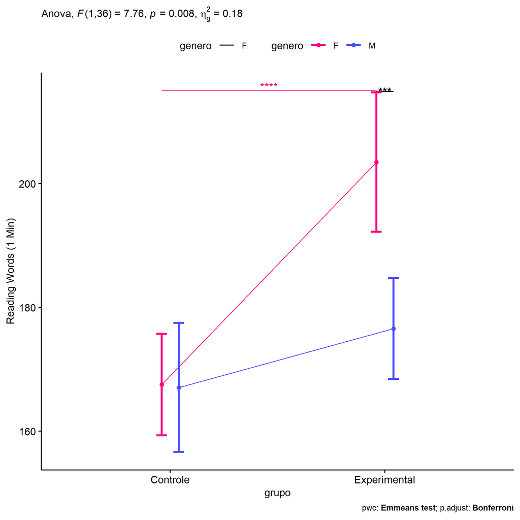

```r
if (length(unique(pdat[["genero"]])) >= 2) {
  ggPlotAoC2(pwcs, "grupo", "genero", aov, ylab = "Reading Words (1 Min)",
             subtitle = which(aov$Effect == "grupo:genero"), addParam = "errorbar") +
    ggplot2::scale_color_manual(values = color[["genero"]]) +
    ggplot2::ylab("Reading Words (1 Min)") +
    if (ymin.ci < ymax.ci) ggplot2::ylim(ymin.ci, ymax.ci)
}
```

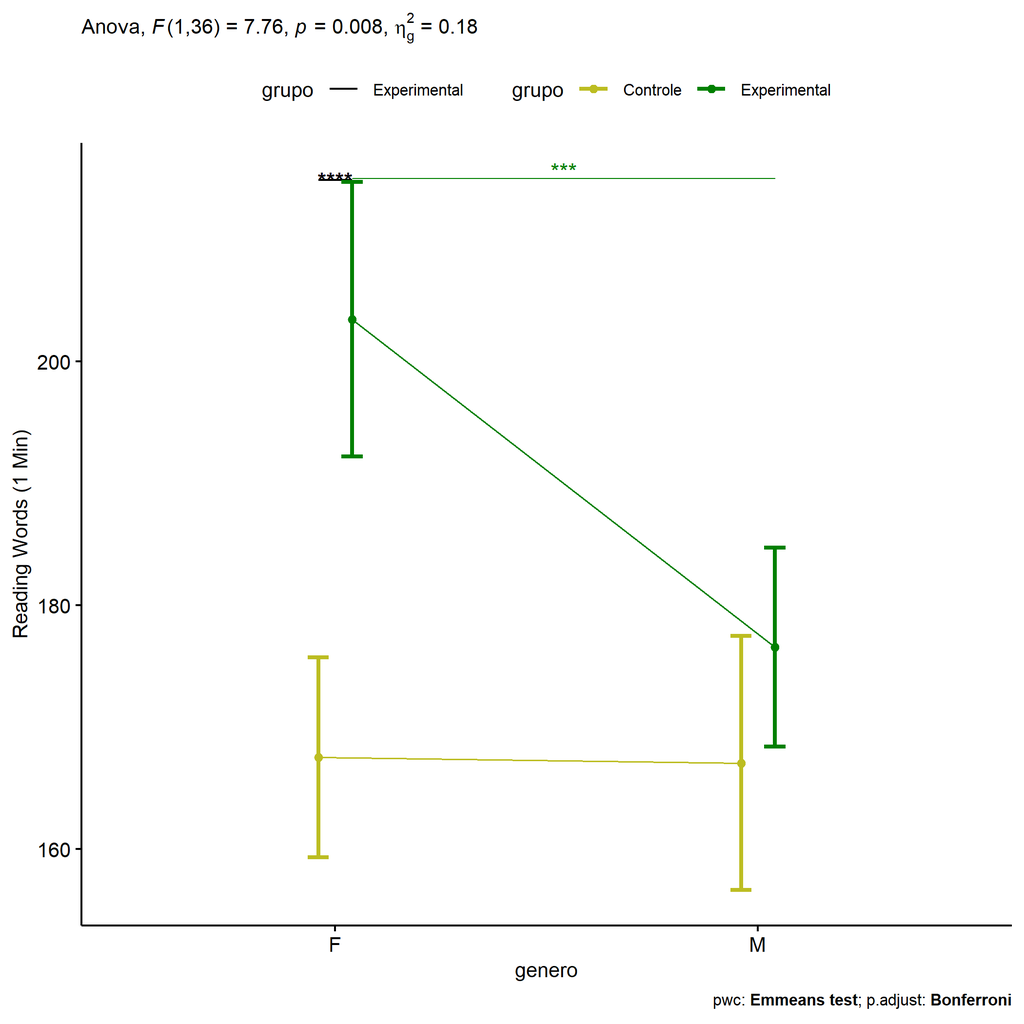

```r
if (length(unique(pdat[["genero"]])) >= 2) {
  ggPlotAoC2(pwcs, "genero", "grupo", aov, ylab = "Reading Words (1 Min)",
               subtitle = which(aov$Effect == "grupo:genero"), addParam = "errorbar") +
    ggplot2::scale_color_manual(values = color[["grupo"]]) +
    ggplot2::ylab("Reading Words (1 Min)") +
    if (ymin.ci < ymax.ci) ggplot2::ylim(ymin.ci, ymax.ci)
}
```

```r
if (length(unique(pdat[["genero"]])) >= 2) {
  plots <- twoWayAncovaBoxPlots(
    wdat, "palavras.lidas.pos", c("grupo","genero"), aov, pwcs, covar = "palavras.lidas.pre",
    theme = "classic", color = color[["grupo:genero"]],
    subtitle = which(aov$Effect == "grupo:genero"))
}
```

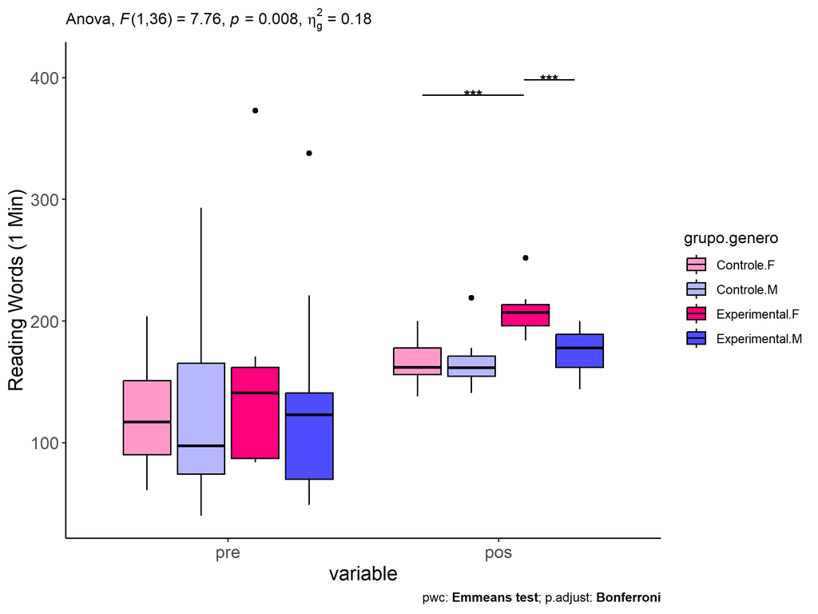

```r
if (length(unique(pdat[["genero"]])) >= 2) {
  plots[["grupo:genero"]] + ggplot2::ylab("Reading Words (1 Min)") +
  ggplot2::scale_x_discrete(labels=c('pre', 'pos')) +
  if (ymin < ymax) ggplot2::ylim(ymin, ymax)
}
```

```r
if (length(unique(pdat[["genero"]])) >= 2) {
  plots <- twoWayAncovaBoxPlots(
    wdat.long, "palavras.lidas", c("grupo","genero"), aov, pwc.long,
    pre.post = "time",
    theme = "classic", color = color$prepost)
}
```

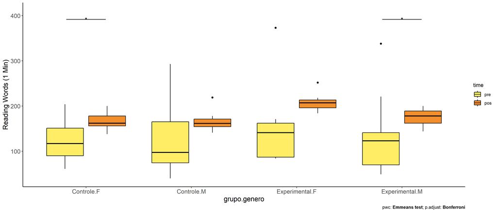

```r
if (length(unique(pdat[["genero"]])) >= 2)
  plots[["grupo:genero"]] + ggplot2::ylab("Reading Words (1 Min)") +
    if (ymin < ymax) ggplot2::ylim(ymin, ymax)
```

### Checking linearity assumption

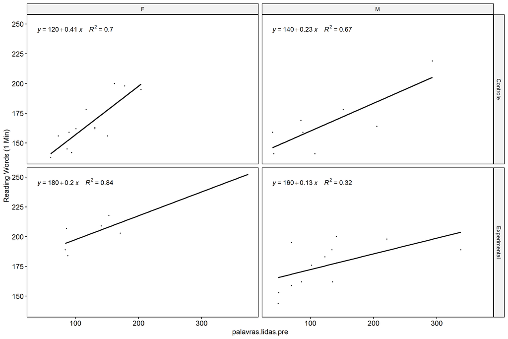

```r
if (length(unique(pdat[["genero"]])) >= 2) {
  ggscatter(wdat, x = "palavras.lidas.pre", y = "palavras.lidas.pos", size = 0.5,
            facet.by = c("grupo","genero"), add = "reg.line")+
    stat_regline_equation(
      aes(label =  paste(..eq.label.., ..rr.label.., sep = "~~~~"))
    ) + ggplot2::ylab("Reading Words (1 Min)") +
    if (ymin < ymax) ggplot2::ylim(ymin, ymax)
}
```

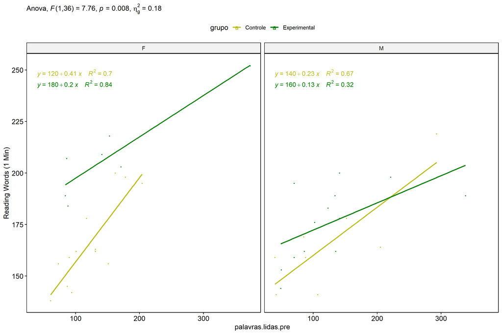

```r
if (length(unique(pdat[["genero"]])) >= 2) {
  ggscatter(wdat, x = "palavras.lidas.pre", y = "palavras.lidas.pos", size = 0.5,
            color = "grupo", facet.by = "genero", add = "reg.line")+
    stat_regline_equation(
      aes(label =  paste(..eq.label.., ..rr.label.., sep = "~~~~"), color = grupo)
    ) +
    ggplot2::labs(subtitle = rstatix::get_test_label(aov, detailed = T, row = which(aov$Effect == "grupo:genero"))) +
    ggplot2::scale_color_manual(values = color[["grupo"]]) +
    ggplot2::ylab("Reading Words (1 Min)") +
    if (ymin < ymax) ggplot2::ylim(ymin, ymax)
}
```

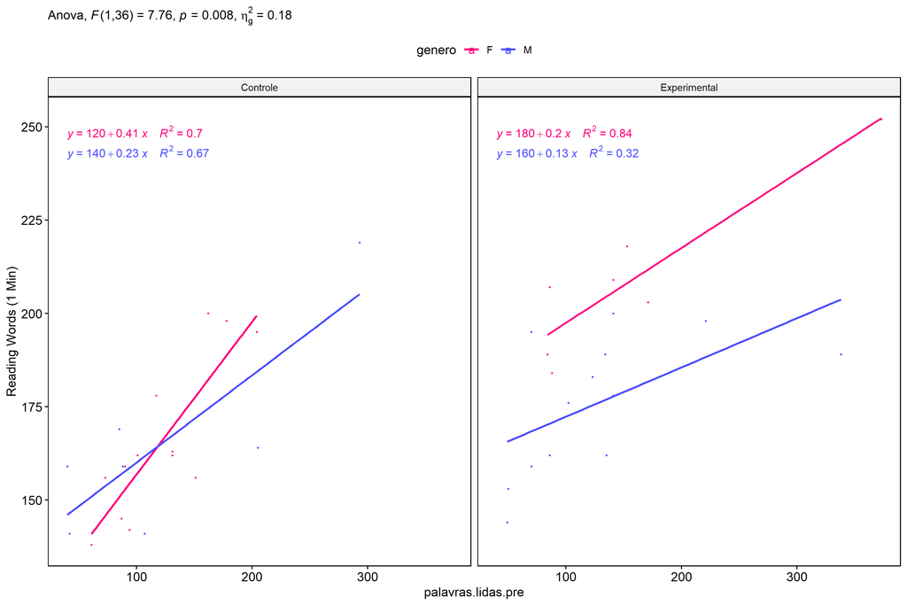

```r
if (length(unique(pdat[["genero"]])) >= 2) {
  ggscatter(wdat, x = "palavras.lidas.pre", y = "palavras.lidas.pos", size = 0.5,
            color = "genero", facet.by = "grupo", add = "reg.line")+
    stat_regline_equation(
      aes(label =  paste(..eq.label.., ..rr.label.., sep = "~~~~"), color = genero)
    ) +
    ggplot2::labs(subtitle = rstatix::get_test_label(aov, detailed = T, row = which(aov$Effect == "grupo:genero"))) +
    ggplot2::scale_color_manual(values = color[["genero"]]) +
    ggplot2::ylab("Reading Words (1 Min)") +
    if (ymin < ymax) ggplot2::ylim(ymin, ymax)
}
```

### Checking normality and homogeneity

```r
if (length(unique(pdat[["genero"]])) >= 2)
  res <- augment(lm(palavras.lidas.pos ~ palavras.lidas.pre + grupo*genero, data = wdat))
```

```r
if (length(unique(pdat[["genero"]])) >= 2)
  shapiro_test(res$.resid)
```

```
## # A tibble: 1 × 3
##   variable   statistic p.value
##   <chr>          <dbl>   <dbl>
## 1 res$.resid     0.989   0.958
```

```r
if (length(unique(pdat[["genero"]])) >= 2)
  levene_test(res, .resid ~ grupo*genero)
```

```
## # A tibble: 1 × 4
##     df1   df2 statistic     p
##   <int> <int>     <dbl> <dbl>
## 1     3    37     0.577 0.634
```

# ANCOVA and Pairwise for two factors **grupo:zona.participante**

## Without remove non-normal data

```r
pdat = remove_group_data(dat[!is.na(dat[["grupo"]]) & !is.na(dat[["zona.participante"]]),],
                         "palavras.lidas.pos", c("grupo","zona.participante"))
pdat = pdat[pdat[["zona.participante"]] %in% do.call(
  intersect, lapply(unique(pdat[["grupo"]]), FUN = function(x) {
    unique(pdat[["zona.participante"]][which(pdat[["grupo"]] == x)])
  })),]
pdat[["grupo"]] = factor(pdat[["grupo"]], level[["grupo"]])
pdat[["zona.participante"]] = factor(
  pdat[["zona.participante"]],
  level[["zona.participante"]][level[["zona.participante"]] %in% unique(pdat[["zona.participante"]])])

pdat.long <- rbind(pdat[,c("id","grupo","zona.participante")], pdat[,c("id","grupo","zona.participante")])
pdat.long[["time"]] <- c(rep("pre", nrow(pdat)), rep("pos", nrow(pdat)))
pdat.long[["time"]] <- factor(pdat.long[["time"]], c("pre","pos"))
pdat.long[["palavras.lidas"]] <- c(pdat[["palavras.lidas.pre"]], pdat[["palavras.lidas.pos"]])

if (length(unique(pdat[["zona.participante"]])) >= 2) {
  aov = anova_test(pdat, palavras.lidas.pos ~ palavras.lidas.pre + grupo*zona.participante)
  laov[["grupo:zona.participante"]] <- get_anova_table(aov)
}
```

```r
if (length(unique(pdat[["zona.participante"]])) >= 2) {
  pwcs <- list()
  pwcs[["zona.participante"]] <- emmeans_test(
    group_by(pdat, grupo), palavras.lidas.pos ~ zona.participante,
    covariate = palavras.lidas.pre, p.adjust.method = "bonferroni")
  pwcs[["grupo"]] <- emmeans_test(
    group_by(pdat, zona.participante), palavras.lidas.pos ~ grupo,
    covariate = palavras.lidas.pre, p.adjust.method = "bonferroni")

  pwc <- plyr::rbind.fill(pwcs[["grupo"]], pwcs[["zona.participante"]])
  pwc <- pwc[,c("grupo","zona.participante", colnames(pwc)[!colnames(pwc) %in% c("grupo","zona.participante")])]
}
```

```r
if (length(unique(pdat[["zona.participante"]])) >= 2) {
  pwc.long <- emmeans_test(dplyr::group_by_at(pdat.long, c("grupo","zona.participante")),
                           palavras.lidas ~ time,
                           p.adjust.method = "bonferroni")
  lpwc[["grupo:zona.participante"]] <- plyr::rbind.fill(pwc, pwc.long)
}
```

```r
if (length(unique(pdat[["zona.participante"]])) >= 2) {
  ds <- get.descriptives(pdat, "palavras.lidas.pos", c("grupo","zona.participante"), covar = "palavras.lidas.pre")
  ds <- merge(ds[ds$variable != "palavras.lidas.pre",],
              ds[ds$variable == "palavras.lidas.pre", !colnames(ds) %in% c("variable")],
              by = c("grupo","zona.participante"), all.x = T, suffixes = c("", ".palavras.lidas.pre"))
  ds <- merge(get_emmeans(pwcs[["grupo"]]), ds,
              by = c("grupo","zona.participante"), suffixes = c(".emms", ""))
  ds <- ds[,c("grupo","zona.participante","n","mean.palavras.lidas.pre","se.palavras.lidas.pre","mean","se",
              "emmean","se.emms","conf.low","conf.high")]

  colnames(ds) <- c("grupo","zona.participante", "N", paste0(c("M","SE")," (pre)"),
                    paste0(c("M","SE"), " (unadj)"),
                    paste0(c("M", "SE"), " (adj)"), "conf.low", "conf.high")

  lemms[["grupo:zona.participante"]] <- ds
}
```

## Computing ANCOVA and PairWise After removing non-normal data (OK)

```r
if (length(unique(pdat[["zona.participante"]])) >= 2) {
  wdat = pdat

  res = residuals(lm(palavras.lidas.pos ~ palavras.lidas.pre + grupo*zona.participante, data = wdat))
  non.normal = getNonNormal(res, wdat$id, plimit = 0.05)

  wdat = wdat[!wdat$id %in% non.normal,]

  wdat.long <- rbind(wdat[,c("id","grupo","zona.participante")], wdat[,c("id","grupo","zona.participante")])
  wdat.long[["time"]] <- c(rep("pre", nrow(wdat)), rep("pos", nrow(wdat)))
  wdat.long[["time"]] <- factor(wdat.long[["time"]], c("pre","pos"))
  wdat.long[["palavras.lidas"]] <- c(wdat[["palavras.lidas.pre"]], wdat[["palavras.lidas.pos"]])


  ldat[["grupo:zona.participante"]] = wdat

  (non.normal)
}
```

```
## [1] "P96"  "P24"  "P171" "P68"  "P353" "P180" "P360" "P94"  "P90"
```

```r
if (length(unique(pdat[["zona.participante"]])) >= 2) {
  aov = anova_test(wdat, palavras.lidas.pos ~ palavras.lidas.pre + grupo*zona.participante)
  laov[["grupo:zona.participante"]] <- merge(get_anova_table(aov), laov[["grupo:zona.participante"]],
                                         by="Effect", suffixes = c("","'"))
  df = get_anova_table(aov)
}
```

| Effect | DFn | DFd | F | p | p<.05 | ges |
| --- | --- | --- | --- | --- | --- | --- |
| palavras.lidas.pre | 1 | 173 | 5.984 | 0.015 | * | 0.033 |
| grupo | 1 | 173 | 10.431 | 0.001 | * | 0.057 |
| zona.participante | 1 | 173 | 0.002 | 0.964 |  | 0.000 |
| grupo:zona.participante | 1 | 173 | 12.836 | 0.000 | * | 0.069 |

```r
if (length(unique(pdat[["zona.participante"]])) >= 2) {
  pwcs <- list()
  pwcs[["zona.participante"]] <- emmeans_test(
    group_by(wdat, grupo), palavras.lidas.pos ~ zona.participante,
    covariate = palavras.lidas.pre, p.adjust.method = "bonferroni")
  pwcs[["grupo"]] <- emmeans_test(
    group_by(wdat, zona.participante), palavras.lidas.pos ~ grupo,
    covariate = palavras.lidas.pre, p.adjust.method = "bonferroni")

  pwc <- plyr::rbind.fill(pwcs[["grupo"]], pwcs[["zona.participante"]])
  pwc <- pwc[,c("grupo","zona.participante", colnames(pwc)[!colnames(pwc) %in% c("grupo","zona.participante")])]
}
```

| grupo | zona.participante | term | .y. | group1 | group2 | df | statistic | p | p.adj | p.adj.signif |
| --- | --- | --- | --- | --- | --- | --- | --- | --- | --- | --- |
|  | Rural | palavras.lidas.pre*grupo | palavras.lidas.pos | Controle | Experimental | 173 | 0.147 | 0.883 | 0.883 | ns |
|  | Urbana | palavras.lidas.pre*grupo | palavras.lidas.pos | Controle | Experimental | 173 | -4.821 | 0.000 | 0.000 | **** |
| Controle |  | palavras.lidas.pre*zona.participante | palavras.lidas.pos | Rural | Urbana | 173 | 2.260 | 0.025 | 0.025 | * |
| Experimental |  | palavras.lidas.pre*zona.participante | palavras.lidas.pos | Rural | Urbana | 173 | -2.774 | 0.006 | 0.006 | ** |

```r
if (length(unique(pdat[["zona.participante"]])) >= 2) {
  pwc.long <- emmeans_test(dplyr::group_by_at(wdat.long, c("grupo","zona.participante")),
                           palavras.lidas ~ time,
                           p.adjust.method = "bonferroni")
  lpwc[["grupo:zona.participante"]] <- merge(plyr::rbind.fill(pwc, pwc.long),
                                         lpwc[["grupo:zona.participante"]],
                                         by=c("grupo","zona.participante","term",".y.","group1","group2"),
                                         suffixes = c("","'"))
}
```

| grupo | zona.participante | term | .y. | group1 | group2 | df | statistic | p | p.adj | p.adj.signif |
| --- | --- | --- | --- | --- | --- | --- | --- | --- | --- | --- |
| Controle | Rural | time | palavras.lidas | pre | pos | 348 | 0.542 | 0.588 | 0.588 | ns |
| Controle | Urbana | time | palavras.lidas | pre | pos | 348 | 2.636 | 0.009 | 0.009 | ** |
| Experimental | Rural | time | palavras.lidas | pre | pos | 348 | 0.668 | 0.505 | 0.505 | ns |
| Experimental | Urbana | time | palavras.lidas | pre | pos | 348 | 0.190 | 0.849 | 0.849 | ns |

```r
if (length(unique(pdat[["zona.participante"]])) >= 2) {
  ds <- get.descriptives(wdat, "palavras.lidas.pos", c("grupo","zona.participante"), covar = "palavras.lidas.pre")
  ds <- merge(ds[ds$variable != "palavras.lidas.pre",],
              ds[ds$variable == "palavras.lidas.pre", !colnames(ds) %in% c("variable")],
              by = c("grupo","zona.participante"), all.x = T, suffixes = c("", ".palavras.lidas.pre"))
  ds <- merge(get_emmeans(pwcs[["grupo"]]), ds,
              by = c("grupo","zona.participante"), suffixes = c(".emms", ""))
  ds <- ds[,c("grupo","zona.participante","n","mean.palavras.lidas.pre","se.palavras.lidas.pre",
              "mean","se","emmean","se.emms","conf.low","conf.high")]

  colnames(ds) <- c("grupo","zona.participante", "N", paste0(c("M","SE")," (pre)"),
                    paste0(c("M","SE"), " (unadj)"),
                    paste0(c("M", "SE"), " (adj)"), "conf.low", "conf.high")

  lemms[["grupo:zona.participante"]] <- merge(ds, lemms[["grupo:zona.participante"]],
                                          by=c("grupo","zona.participante"), suffixes = c("","'"))
}
```

| grupo | zona.participante | N | M (pre) | SE (pre) | M (unadj) | SE (unadj) | M (adj) | SE (adj) | conf.low | conf.high |
| --- | --- | --- | --- | --- | --- | --- | --- | --- | --- | --- |
| Controle | Rural | 47 | 124.404 | 11.531 | 116.553 | 7.025 | 117.253 | 6.627 | 104.173 | 130.332 |
| Controle | Urbana | 57 | 131.737 | 11.861 | 97.035 | 5.586 | 97.034 | 6.012 | 85.168 | 108.900 |
| Experimental | Rural | 42 | 125.476 | 14.288 | 115.238 | 6.529 | 115.835 | 7.008 | 102.004 | 129.667 |
| Experimental | Urbana | 32 | 150.656 | 16.241 | 147.312 | 9.473 | 145.503 | 8.058 | 129.600 | 161.407 |

### Plots for ancova

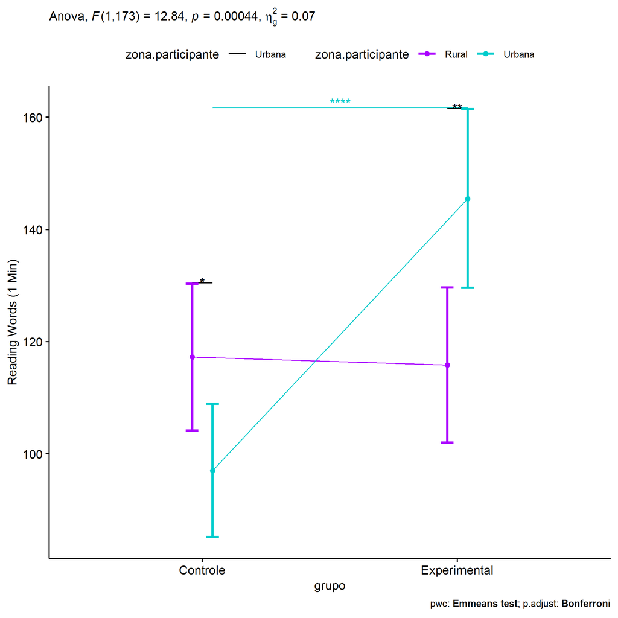

```r
if (length(unique(pdat[["zona.participante"]])) >= 2) {
  ggPlotAoC2(pwcs, "grupo", "zona.participante", aov, ylab = "Reading Words (1 Min)",
             subtitle = which(aov$Effect == "grupo:zona.participante"), addParam = "errorbar") +
    ggplot2::scale_color_manual(values = color[["zona.participante"]]) +
    ggplot2::ylab("Reading Words (1 Min)") +
    if (ymin.ci < ymax.ci) ggplot2::ylim(ymin.ci, ymax.ci)
}
```

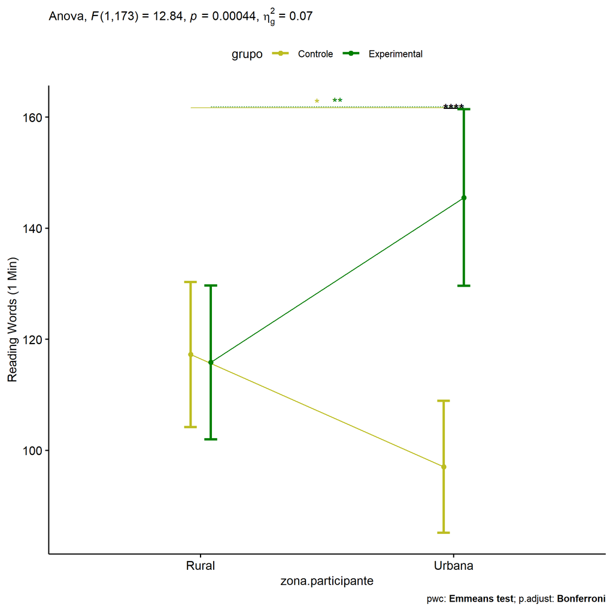

```r
if (length(unique(pdat[["zona.participante"]])) >= 2) {
  ggPlotAoC2(pwcs, "zona.participante", "grupo", aov, ylab = "Reading Words (1 Min)",
               subtitle = which(aov$Effect == "grupo:zona.participante"), addParam = "errorbar") +
    ggplot2::scale_color_manual(values = color[["grupo"]]) +
    ggplot2::ylab("Reading Words (1 Min)") +
    if (ymin.ci < ymax.ci) ggplot2::ylim(ymin.ci, ymax.ci)
}
```

```r
if (length(unique(pdat[["zona.participante"]])) >= 2) {
  plots <- twoWayAncovaBoxPlots(
    wdat, "palavras.lidas.pos", c("grupo","zona.participante"), aov, pwcs, covar = "palavras.lidas.pre",
    theme = "classic", color = color[["grupo:zona.participante"]],
    subtitle = which(aov$Effect == "grupo:zona.participante"))
}
```

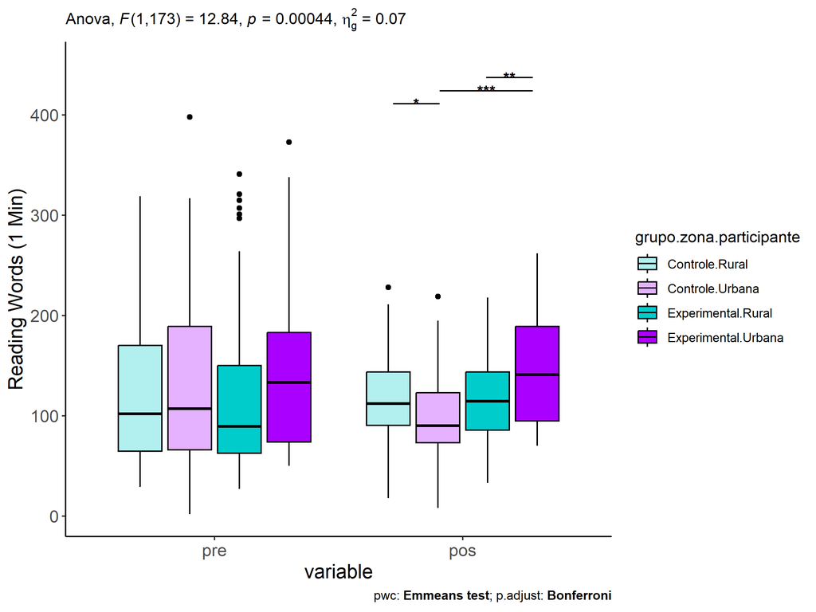

```r
if (length(unique(pdat[["zona.participante"]])) >= 2) {
  plots[["grupo:zona.participante"]] + ggplot2::ylab("Reading Words (1 Min)") +
  ggplot2::scale_x_discrete(labels=c('pre', 'pos')) +
  if (ymin < ymax) ggplot2::ylim(ymin, ymax)
}
```

```r
if (length(unique(pdat[["zona.participante"]])) >= 2) {
  plots <- twoWayAncovaBoxPlots(
    wdat.long, "palavras.lidas", c("grupo","zona.participante"), aov, pwc.long,
    pre.post = "time",
    theme = "classic", color = color$prepost)
}
```

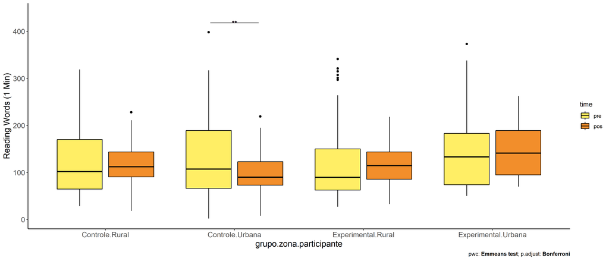

```r
if (length(unique(pdat[["zona.participante"]])) >= 2)
  plots[["grupo:zona.participante"]] + ggplot2::ylab("Reading Words (1 Min)") +
    if (ymin < ymax) ggplot2::ylim(ymin, ymax)
```

### Checking linearity assumption

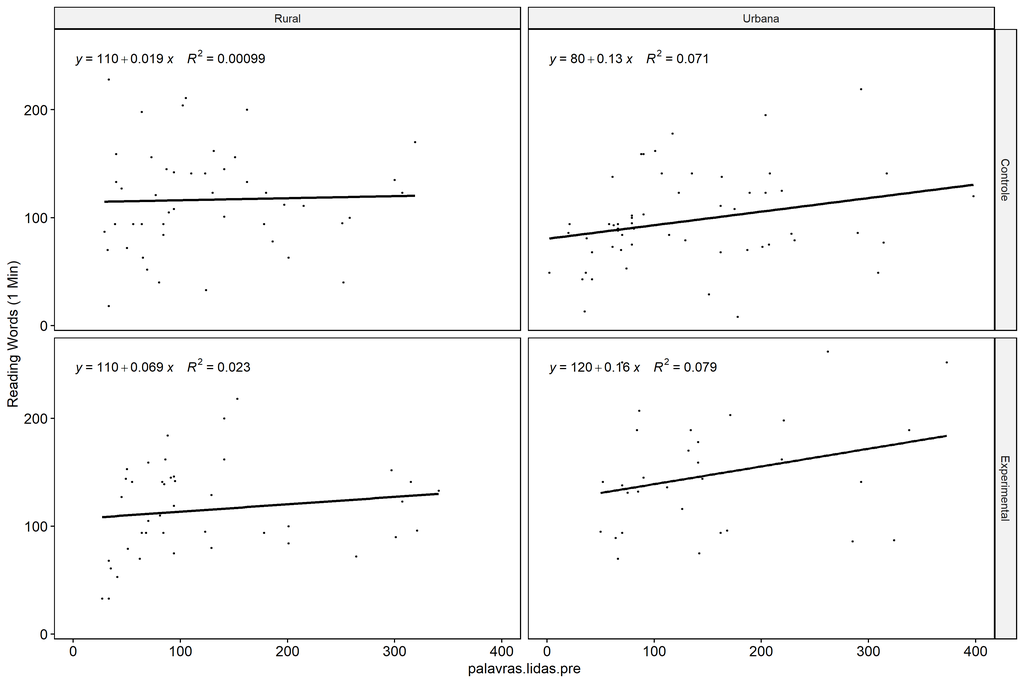

```r
if (length(unique(pdat[["zona.participante"]])) >= 2) {
  ggscatter(wdat, x = "palavras.lidas.pre", y = "palavras.lidas.pos", size = 0.5,
            facet.by = c("grupo","zona.participante"), add = "reg.line")+
    stat_regline_equation(
      aes(label =  paste(..eq.label.., ..rr.label.., sep = "~~~~"))
    ) + ggplot2::ylab("Reading Words (1 Min)") +
    if (ymin < ymax) ggplot2::ylim(ymin, ymax)
}
```

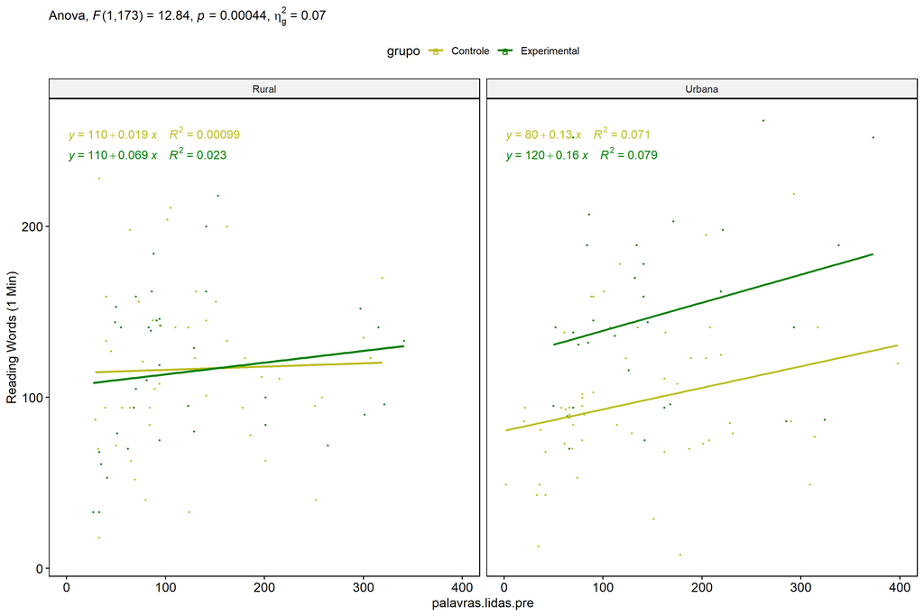

```r
if (length(unique(pdat[["zona.participante"]])) >= 2) {
  ggscatter(wdat, x = "palavras.lidas.pre", y = "palavras.lidas.pos", size = 0.5,
            color = "grupo", facet.by = "zona.participante", add = "reg.line")+
    stat_regline_equation(
      aes(label =  paste(..eq.label.., ..rr.label.., sep = "~~~~"), color = grupo)
    ) +
    ggplot2::labs(subtitle = rstatix::get_test_label(aov, detailed = T, row = which(aov$Effect == "grupo:zona.participante"))) +
    ggplot2::scale_color_manual(values = color[["grupo"]]) +
    ggplot2::ylab("Reading Words (1 Min)") +
    if (ymin < ymax) ggplot2::ylim(ymin, ymax)
}
```

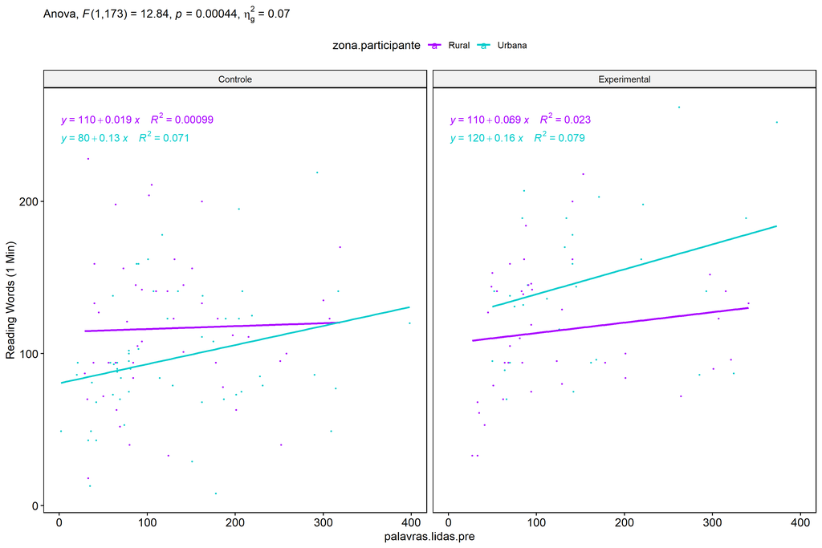

```r
if (length(unique(pdat[["zona.participante"]])) >= 2) {
  ggscatter(wdat, x = "palavras.lidas.pre", y = "palavras.lidas.pos", size = 0.5,
            color = "zona.participante", facet.by = "grupo", add = "reg.line")+
    stat_regline_equation(
      aes(label =  paste(..eq.label.., ..rr.label.., sep = "~~~~"), color = zona.participante)
    ) +
    ggplot2::labs(subtitle = rstatix::get_test_label(aov, detailed = T, row = which(aov$Effect == "grupo:zona.participante"))) +
    ggplot2::scale_color_manual(values = color[["zona.participante"]]) +
    ggplot2::ylab("Reading Words (1 Min)") +
    if (ymin < ymax) ggplot2::ylim(ymin, ymax)
}
```

### Checking normality and homogeneity

```r
if (length(unique(pdat[["zona.participante"]])) >= 2)
  res <- augment(lm(palavras.lidas.pos ~ palavras.lidas.pre + grupo*zona.participante, data = wdat))
```

```r
if (length(unique(pdat[["zona.participante"]])) >= 2)
  shapiro_test(res$.resid)
```

```
## # A tibble: 1 × 3
##   variable   statistic p.value
##   <chr>          <dbl>   <dbl>
## 1 res$.resid     0.985  0.0510
```

```r
if (length(unique(pdat[["zona.participante"]])) >= 2)
  levene_test(res, .resid ~ grupo*zona.participante)
```

```
## # A tibble: 1 × 4
##     df1   df2 statistic     p
##   <int> <int>     <dbl> <dbl>
## 1     3   174      1.17 0.322
```

# ANCOVA and Pairwise for two factors **grupo:zona.escola**

## Without remove non-normal data

```r
pdat = remove_group_data(dat[!is.na(dat[["grupo"]]) & !is.na(dat[["zona.escola"]]),],
                         "palavras.lidas.pos", c("grupo","zona.escola"))
pdat = pdat[pdat[["zona.escola"]] %in% do.call(
  intersect, lapply(unique(pdat[["grupo"]]), FUN = function(x) {
    unique(pdat[["zona.escola"]][which(pdat[["grupo"]] == x)])
  })),]
pdat[["grupo"]] = factor(pdat[["grupo"]], level[["grupo"]])
pdat[["zona.escola"]] = factor(
  pdat[["zona.escola"]],
  level[["zona.escola"]][level[["zona.escola"]] %in% unique(pdat[["zona.escola"]])])

pdat.long <- rbind(pdat[,c("id","grupo","zona.escola")], pdat[,c("id","grupo","zona.escola")])
pdat.long[["time"]] <- c(rep("pre", nrow(pdat)), rep("pos", nrow(pdat)))
pdat.long[["time"]] <- factor(pdat.long[["time"]], c("pre","pos"))
pdat.long[["palavras.lidas"]] <- c(pdat[["palavras.lidas.pre"]], pdat[["palavras.lidas.pos"]])

if (length(unique(pdat[["zona.escola"]])) >= 2) {
  aov = anova_test(pdat, palavras.lidas.pos ~ palavras.lidas.pre + grupo*zona.escola)
  laov[["grupo:zona.escola"]] <- get_anova_table(aov)
}
```

```r
if (length(unique(pdat[["zona.escola"]])) >= 2) {
  pwcs <- list()
  pwcs[["zona.escola"]] <- emmeans_test(
    group_by(pdat, grupo), palavras.lidas.pos ~ zona.escola,
    covariate = palavras.lidas.pre, p.adjust.method = "bonferroni")
  pwcs[["grupo"]] <- emmeans_test(
    group_by(pdat, zona.escola), palavras.lidas.pos ~ grupo,
    covariate = palavras.lidas.pre, p.adjust.method = "bonferroni")

  pwc <- plyr::rbind.fill(pwcs[["grupo"]], pwcs[["zona.escola"]])
  pwc <- pwc[,c("grupo","zona.escola", colnames(pwc)[!colnames(pwc) %in% c("grupo","zona.escola")])]
}
```

```r
if (length(unique(pdat[["zona.escola"]])) >= 2) {
  pwc.long <- emmeans_test(dplyr::group_by_at(pdat.long, c("grupo","zona.escola")),
                           palavras.lidas ~ time,
                           p.adjust.method = "bonferroni")
  lpwc[["grupo:zona.escola"]] <- plyr::rbind.fill(pwc, pwc.long)
}
```

```r
if (length(unique(pdat[["zona.escola"]])) >= 2) {
  ds <- get.descriptives(pdat, "palavras.lidas.pos", c("grupo","zona.escola"), covar = "palavras.lidas.pre")
  ds <- merge(ds[ds$variable != "palavras.lidas.pre",],
              ds[ds$variable == "palavras.lidas.pre", !colnames(ds) %in% c("variable")],
              by = c("grupo","zona.escola"), all.x = T, suffixes = c("", ".palavras.lidas.pre"))
  ds <- merge(get_emmeans(pwcs[["grupo"]]), ds,
              by = c("grupo","zona.escola"), suffixes = c(".emms", ""))
  ds <- ds[,c("grupo","zona.escola","n","mean.palavras.lidas.pre","se.palavras.lidas.pre","mean","se",
              "emmean","se.emms","conf.low","conf.high")]

  colnames(ds) <- c("grupo","zona.escola", "N", paste0(c("M","SE")," (pre)"),
                    paste0(c("M","SE"), " (unadj)"),
                    paste0(c("M", "SE"), " (adj)"), "conf.low", "conf.high")

  lemms[["grupo:zona.escola"]] <- ds
}
```

## Computing ANCOVA and PairWise After removing non-normal data (OK)

```r
if (length(unique(pdat[["zona.escola"]])) >= 2) {
  wdat = pdat

  res = residuals(lm(palavras.lidas.pos ~ palavras.lidas.pre + grupo*zona.escola, data = wdat))
  non.normal = getNonNormal(res, wdat$id, plimit = 0.05)

  wdat = wdat[!wdat$id %in% non.normal,]

  wdat.long <- rbind(wdat[,c("id","grupo","zona.escola")], wdat[,c("id","grupo","zona.escola")])
  wdat.long[["time"]] <- c(rep("pre", nrow(wdat)), rep("pos", nrow(wdat)))
  wdat.long[["time"]] <- factor(wdat.long[["time"]], c("pre","pos"))
  wdat.long[["palavras.lidas"]] <- c(wdat[["palavras.lidas.pre"]], wdat[["palavras.lidas.pos"]])


  ldat[["grupo:zona.escola"]] = wdat

  (non.normal)
}
```

```
##  [1] "P96"  "P171" "P24"  "P172" "P68"  "P353" "P94"  "P2"   "P37"  "P40"  "P16"  "P102" "P241"
## [14] "P90"
```

```r
if (length(unique(pdat[["zona.escola"]])) >= 2) {
  aov = anova_test(wdat, palavras.lidas.pos ~ palavras.lidas.pre + grupo*zona.escola)
  laov[["grupo:zona.escola"]] <- merge(get_anova_table(aov), laov[["grupo:zona.escola"]],
                                         by="Effect", suffixes = c("","'"))
  df = get_anova_table(aov)
}
```

| Effect | DFn | DFd | F | p | p<.05 | ges |
| --- | --- | --- | --- | --- | --- | --- |
| palavras.lidas.pre | 1 | 222 | 22.864 | 0.000 | * | 0.093 |
| grupo | 1 | 222 | 11.091 | 0.001 | * | 0.048 |
| zona.escola | 1 | 222 | 26.182 | 0.000 | * | 0.105 |
| grupo:zona.escola | 1 | 222 | 3.501 | 0.063 |  | 0.016 |

```r
if (length(unique(pdat[["zona.escola"]])) >= 2) {
  pwcs <- list()
  pwcs[["zona.escola"]] <- emmeans_test(
    group_by(wdat, grupo), palavras.lidas.pos ~ zona.escola,
    covariate = palavras.lidas.pre, p.adjust.method = "bonferroni")
  pwcs[["grupo"]] <- emmeans_test(
    group_by(wdat, zona.escola), palavras.lidas.pos ~ grupo,
    covariate = palavras.lidas.pre, p.adjust.method = "bonferroni")

  pwc <- plyr::rbind.fill(pwcs[["grupo"]], pwcs[["zona.escola"]])
  pwc <- pwc[,c("grupo","zona.escola", colnames(pwc)[!colnames(pwc) %in% c("grupo","zona.escola")])]
}
```

| grupo | zona.escola | term | .y. | group1 | group2 | df | statistic | p | p.adj | p.adj.signif |
| --- | --- | --- | --- | --- | --- | --- | --- | --- | --- | --- |
|  | Rural | palavras.lidas.pre*grupo | palavras.lidas.pos | Controle | Experimental | 222 | -0.581 | 0.562 | 0.562 | ns |
|  | Urbana | palavras.lidas.pre*grupo | palavras.lidas.pos | Controle | Experimental | 222 | -3.771 | 0.000 | 0.000 | *** |
| Controle |  | palavras.lidas.pre*zona.escola | palavras.lidas.pos | Rural | Urbana | 222 | -2.684 | 0.008 | 0.008 | ** |
| Experimental |  | palavras.lidas.pre*zona.escola | palavras.lidas.pos | Rural | Urbana | 222 | -4.817 | 0.000 | 0.000 | **** |

```r
if (length(unique(pdat[["zona.escola"]])) >= 2) {
  pwc.long <- emmeans_test(dplyr::group_by_at(wdat.long, c("grupo","zona.escola")),
                           palavras.lidas ~ time,
                           p.adjust.method = "bonferroni")
  lpwc[["grupo:zona.escola"]] <- merge(plyr::rbind.fill(pwc, pwc.long),
                                         lpwc[["grupo:zona.escola"]],
                                         by=c("grupo","zona.escola","term",".y.","group1","group2"),
                                         suffixes = c("","'"))
}
```

| grupo | zona.escola | term | .y. | group1 | group2 | df | statistic | p | p.adj | p.adj.signif |
| --- | --- | --- | --- | --- | --- | --- | --- | --- | --- | --- |
| Controle | Rural | time | palavras.lidas | pre | pos | 446 | 4.754 | 0.000 | 0.000 | **** |
| Controle | Urbana | time | palavras.lidas | pre | pos | 446 | -1.426 | 0.154 | 0.154 | ns |
| Experimental | Rural | time | palavras.lidas | pre | pos | 446 | 2.595 | 0.010 | 0.010 | ** |
| Experimental | Urbana | time | palavras.lidas | pre | pos | 446 | -2.086 | 0.038 | 0.038 | * |

```r
if (length(unique(pdat[["zona.escola"]])) >= 2) {
  ds <- get.descriptives(wdat, "palavras.lidas.pos", c("grupo","zona.escola"), covar = "palavras.lidas.pre")
  ds <- merge(ds[ds$variable != "palavras.lidas.pre",],
              ds[ds$variable == "palavras.lidas.pre", !colnames(ds) %in% c("variable")],
              by = c("grupo","zona.escola"), all.x = T, suffixes = c("", ".palavras.lidas.pre"))
  ds <- merge(get_emmeans(pwcs[["grupo"]]), ds,
              by = c("grupo","zona.escola"), suffixes = c(".emms", ""))
  ds <- ds[,c("grupo","zona.escola","n","mean.palavras.lidas.pre","se.palavras.lidas.pre",
              "mean","se","emmean","se.emms","conf.low","conf.high")]

  colnames(ds) <- c("grupo","zona.escola", "N", paste0(c("M","SE")," (pre)"),
                    paste0(c("M","SE"), " (unadj)"),
                    paste0(c("M", "SE"), " (adj)"), "conf.low", "conf.high")

  lemms[["grupo:zona.escola"]] <- merge(ds, lemms[["grupo:zona.escola"]],
                                          by=c("grupo","zona.escola"), suffixes = c("","'"))
}
```

| grupo | zona.escola | N | M (pre) | SE (pre) | M (unadj) | SE (unadj) | M (adj) | SE (adj) | conf.low | conf.high |
| --- | --- | --- | --- | --- | --- | --- | --- | --- | --- | --- |
| Controle | Rural | 51 | 163.059 | 13.375 | 101.863 | 6.074 | 95.348 | 6.170 | 83.189 | 107.508 |
| Controle | Urbana | 81 | 97.617 | 6.713 | 112.185 | 5.388 | 116.909 | 4.876 | 107.299 | 126.518 |
| Experimental | Rural | 36 | 143.750 | 17.200 | 104.000 | 5.737 | 100.801 | 7.194 | 86.624 | 114.979 |
| Experimental | Urbana | 59 | 118.729 | 9.536 | 143.695 | 6.129 | 144.793 | 5.600 | 133.757 | 155.829 |

### Plots for ancova

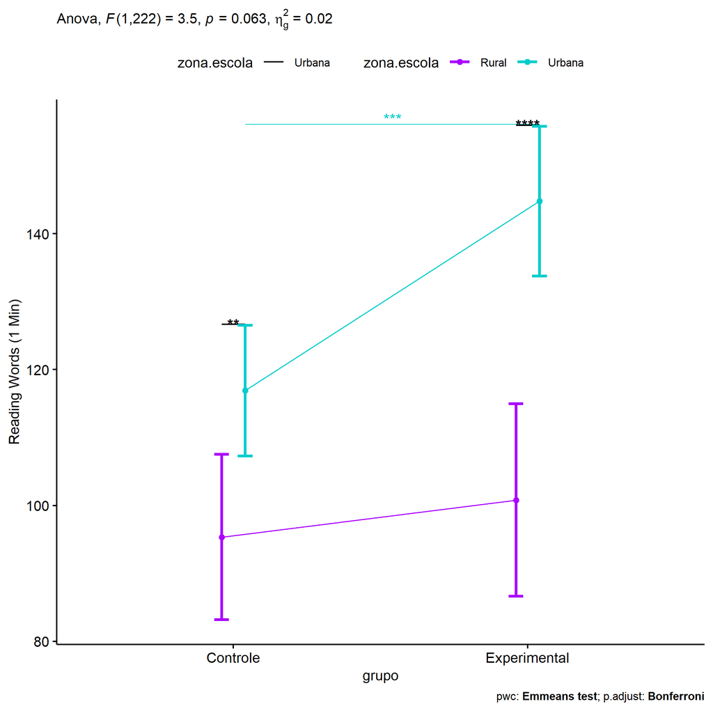

```r
if (length(unique(pdat[["zona.escola"]])) >= 2) {
  ggPlotAoC2(pwcs, "grupo", "zona.escola", aov, ylab = "Reading Words (1 Min)",
             subtitle = which(aov$Effect == "grupo:zona.escola"), addParam = "errorbar") +
    ggplot2::scale_color_manual(values = color[["zona.escola"]]) +
    ggplot2::ylab("Reading Words (1 Min)") +
    if (ymin.ci < ymax.ci) ggplot2::ylim(ymin.ci, ymax.ci)
}
```

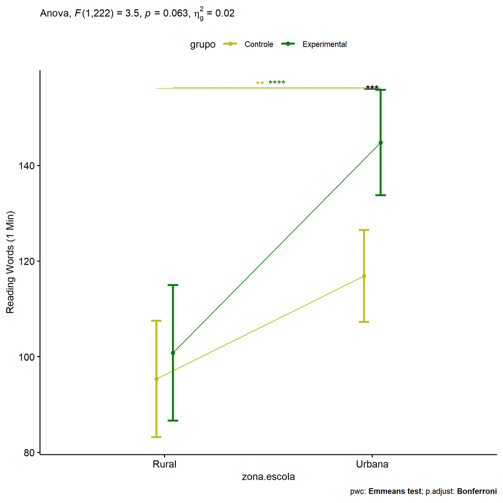

```r
if (length(unique(pdat[["zona.escola"]])) >= 2) {
  ggPlotAoC2(pwcs, "zona.escola", "grupo", aov, ylab = "Reading Words (1 Min)",
               subtitle = which(aov$Effect == "grupo:zona.escola"), addParam = "errorbar") +
    ggplot2::scale_color_manual(values = color[["grupo"]]) +
    ggplot2::ylab("Reading Words (1 Min)") +
    if (ymin.ci < ymax.ci) ggplot2::ylim(ymin.ci, ymax.ci)
}
```

```r
if (length(unique(pdat[["zona.escola"]])) >= 2) {
  plots <- twoWayAncovaBoxPlots(
    wdat, "palavras.lidas.pos", c("grupo","zona.escola"), aov, pwcs, covar = "palavras.lidas.pre",
    theme = "classic", color = color[["grupo:zona.escola"]],
    subtitle = which(aov$Effect == "grupo:zona.escola"))
}
```

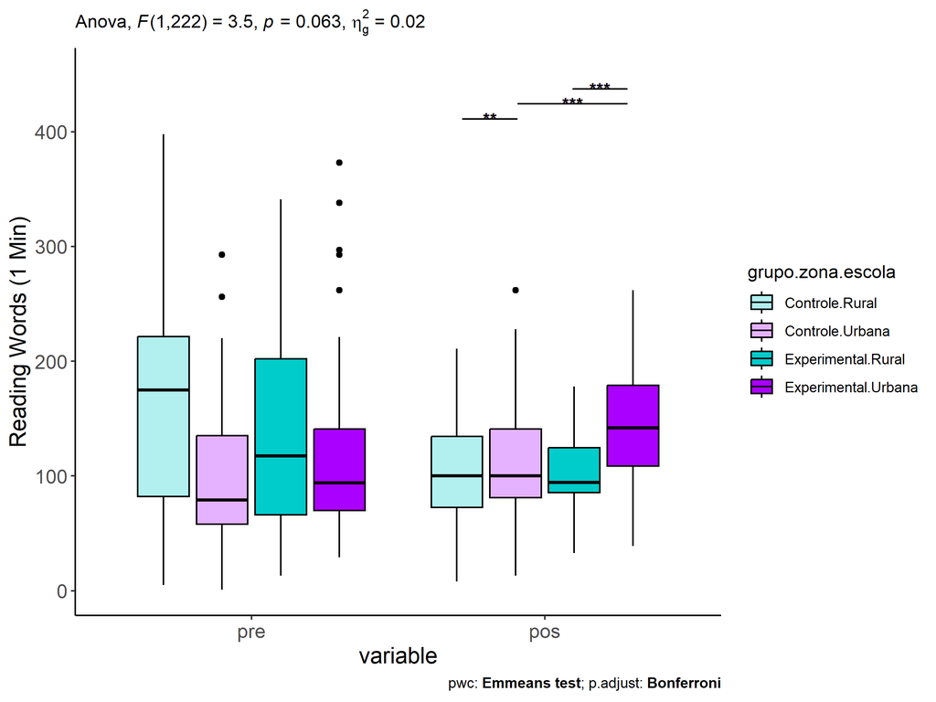

```r
if (length(unique(pdat[["zona.escola"]])) >= 2) {
  plots[["grupo:zona.escola"]] + ggplot2::ylab("Reading Words (1 Min)") +
  ggplot2::scale_x_discrete(labels=c('pre', 'pos')) +
  if (ymin < ymax) ggplot2::ylim(ymin, ymax)
}
```

```r
if (length(unique(pdat[["zona.escola"]])) >= 2) {
  plots <- twoWayAncovaBoxPlots(
    wdat.long, "palavras.lidas", c("grupo","zona.escola"), aov, pwc.long,
    pre.post = "time",
    theme = "classic", color = color$prepost)
}
```

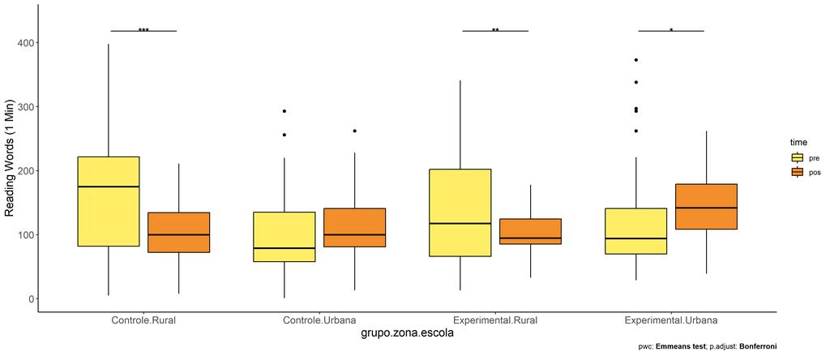

```r
if (length(unique(pdat[["zona.escola"]])) >= 2)
  plots[["grupo:zona.escola"]] + ggplot2::ylab("Reading Words (1 Min)") +
    if (ymin < ymax) ggplot2::ylim(ymin, ymax)
```

### Checking linearity assumption

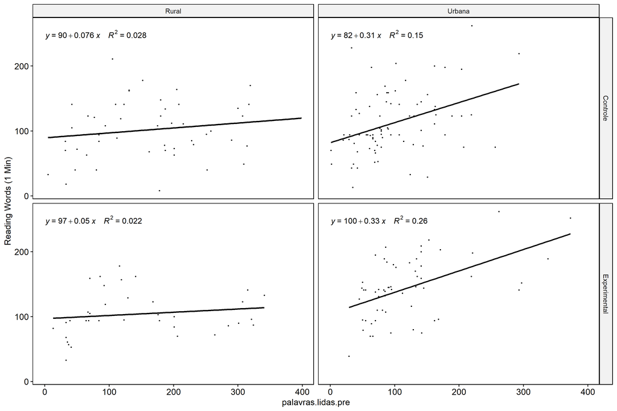

```r
if (length(unique(pdat[["zona.escola"]])) >= 2) {
  ggscatter(wdat, x = "palavras.lidas.pre", y = "palavras.lidas.pos", size = 0.5,
            facet.by = c("grupo","zona.escola"), add = "reg.line")+
    stat_regline_equation(
      aes(label =  paste(..eq.label.., ..rr.label.., sep = "~~~~"))
    ) + ggplot2::ylab("Reading Words (1 Min)") +
    if (ymin < ymax) ggplot2::ylim(ymin, ymax)
}
```

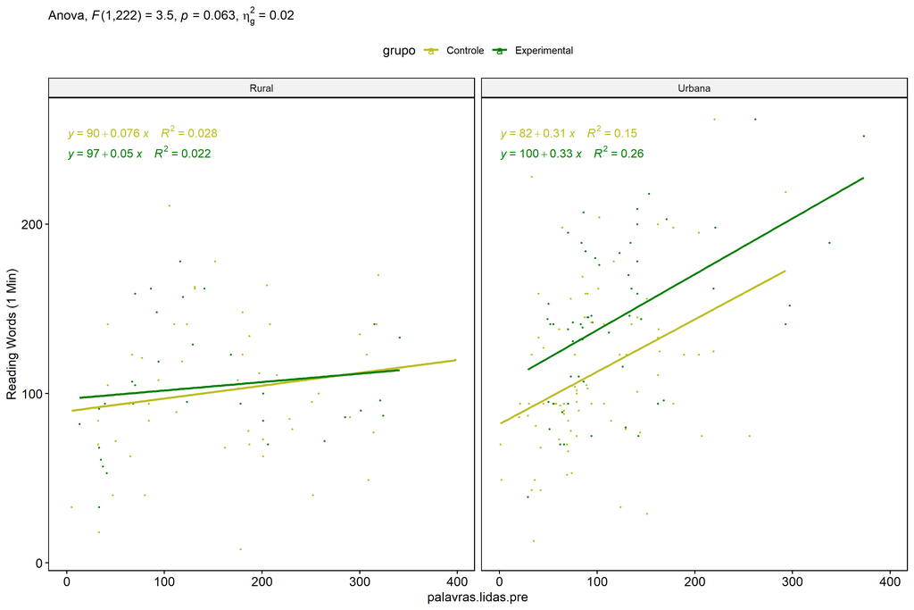

```r
if (length(unique(pdat[["zona.escola"]])) >= 2) {
  ggscatter(wdat, x = "palavras.lidas.pre", y = "palavras.lidas.pos", size = 0.5,
            color = "grupo", facet.by = "zona.escola", add = "reg.line")+
    stat_regline_equation(
      aes(label =  paste(..eq.label.., ..rr.label.., sep = "~~~~"), color = grupo)
    ) +
    ggplot2::labs(subtitle = rstatix::get_test_label(aov, detailed = T, row = which(aov$Effect == "grupo:zona.escola"))) +
    ggplot2::scale_color_manual(values = color[["grupo"]]) +
    ggplot2::ylab("Reading Words (1 Min)") +
    if (ymin < ymax) ggplot2::ylim(ymin, ymax)
}
```

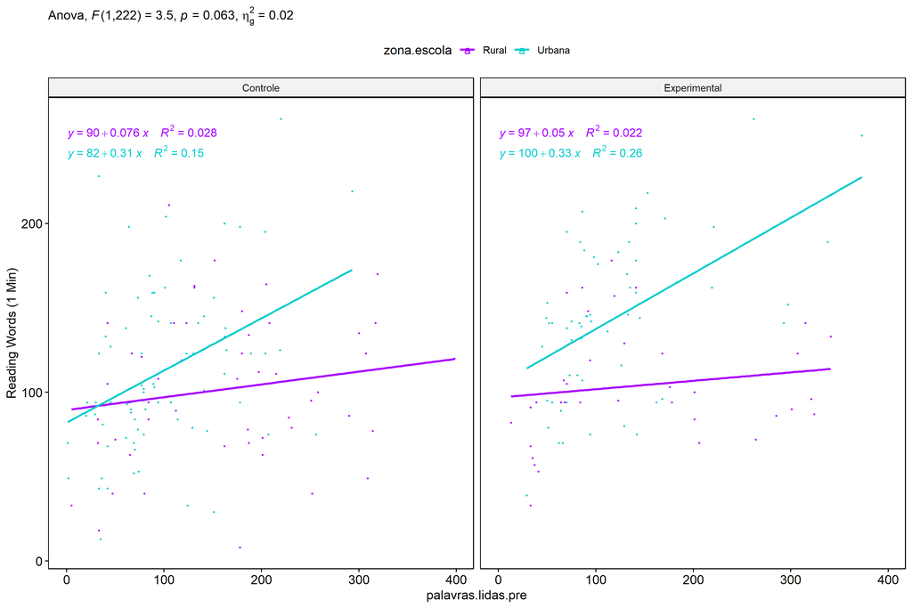

```r
if (length(unique(pdat[["zona.escola"]])) >= 2) {
  ggscatter(wdat, x = "palavras.lidas.pre", y = "palavras.lidas.pos", size = 0.5,
            color = "zona.escola", facet.by = "grupo", add = "reg.line")+
    stat_regline_equation(
      aes(label =  paste(..eq.label.., ..rr.label.., sep = "~~~~"), color = zona.escola)
    ) +
    ggplot2::labs(subtitle = rstatix::get_test_label(aov, detailed = T, row = which(aov$Effect == "grupo:zona.escola"))) +
    ggplot2::scale_color_manual(values = color[["zona.escola"]]) +
    ggplot2::ylab("Reading Words (1 Min)") +
    if (ymin < ymax) ggplot2::ylim(ymin, ymax)
}
```

### Checking normality and homogeneity

```r
if (length(unique(pdat[["zona.escola"]])) >= 2)
  res <- augment(lm(palavras.lidas.pos ~ palavras.lidas.pre + grupo*zona.escola, data = wdat))
```

```r
if (length(unique(pdat[["zona.escola"]])) >= 2)
  shapiro_test(res$.resid)
```

```
## # A tibble: 1 × 3
##   variable   statistic p.value
##   <chr>          <dbl>   <dbl>
## 1 res$.resid     0.988  0.0586
```

```r
if (length(unique(pdat[["zona.escola"]])) >= 2)
  levene_test(res, .resid ~ grupo*zona.escola)
```

```
## # A tibble: 1 × 4
##     df1   df2 statistic     p
##   <int> <int>     <dbl> <dbl>
## 1     3   223     0.474 0.701
```

# ANCOVA and Pairwise for two factors **grupo:palavras.lidas.quintile**

## Without remove non-normal data

```r
pdat = remove_group_data(dat[!is.na(dat[["grupo"]]) & !is.na(dat[["palavras.lidas.quintile"]]),],
                         "palavras.lidas.pos", c("grupo","palavras.lidas.quintile"))
pdat = pdat[pdat[["palavras.lidas.quintile"]] %in% do.call(
  intersect, lapply(unique(pdat[["grupo"]]), FUN = function(x) {
    unique(pdat[["palavras.lidas.quintile"]][which(pdat[["grupo"]] == x)])
  })),]
pdat[["grupo"]] = factor(pdat[["grupo"]], level[["grupo"]])
pdat[["palavras.lidas.quintile"]] = factor(
  pdat[["palavras.lidas.quintile"]],
  level[["palavras.lidas.quintile"]][level[["palavras.lidas.quintile"]] %in% unique(pdat[["palavras.lidas.quintile"]])])

pdat.long <- rbind(pdat[,c("id","grupo","palavras.lidas.quintile")], pdat[,c("id","grupo","palavras.lidas.quintile")])
pdat.long[["time"]] <- c(rep("pre", nrow(pdat)), rep("pos", nrow(pdat)))
pdat.long[["time"]] <- factor(pdat.long[["time"]], c("pre","pos"))
pdat.long[["palavras.lidas"]] <- c(pdat[["palavras.lidas.pre"]], pdat[["palavras.lidas.pos"]])

if (length(unique(pdat[["palavras.lidas.quintile"]])) >= 2) {
  aov = anova_test(pdat, palavras.lidas.pos ~ palavras.lidas.pre + grupo*palavras.lidas.quintile)
  laov[["grupo:palavras.lidas.quintile"]] <- get_anova_table(aov)
}
```

```r
if (length(unique(pdat[["palavras.lidas.quintile"]])) >= 2) {
  pwcs <- list()
  pwcs[["palavras.lidas.quintile"]] <- emmeans_test(
    group_by(pdat, grupo), palavras.lidas.pos ~ palavras.lidas.quintile,
    covariate = palavras.lidas.pre, p.adjust.method = "bonferroni")
  pwcs[["grupo"]] <- emmeans_test(
    group_by(pdat, palavras.lidas.quintile), palavras.lidas.pos ~ grupo,
    covariate = palavras.lidas.pre, p.adjust.method = "bonferroni")

  pwc <- plyr::rbind.fill(pwcs[["grupo"]], pwcs[["palavras.lidas.quintile"]])
  pwc <- pwc[,c("grupo","palavras.lidas.quintile", colnames(pwc)[!colnames(pwc) %in% c("grupo","palavras.lidas.quintile")])]
}
```

```r
if (length(unique(pdat[["palavras.lidas.quintile"]])) >= 2) {
  pwc.long <- emmeans_test(dplyr::group_by_at(pdat.long, c("grupo","palavras.lidas.quintile")),
                           palavras.lidas ~ time,
                           p.adjust.method = "bonferroni")
  lpwc[["grupo:palavras.lidas.quintile"]] <- plyr::rbind.fill(pwc, pwc.long)
}
```

```r
if (length(unique(pdat[["palavras.lidas.quintile"]])) >= 2) {
  ds <- get.descriptives(pdat, "palavras.lidas.pos", c("grupo","palavras.lidas.quintile"), covar = "palavras.lidas.pre")
  ds <- merge(ds[ds$variable != "palavras.lidas.pre",],
              ds[ds$variable == "palavras.lidas.pre", !colnames(ds) %in% c("variable")],
              by = c("grupo","palavras.lidas.quintile"), all.x = T, suffixes = c("", ".palavras.lidas.pre"))
  ds <- merge(get_emmeans(pwcs[["grupo"]]), ds,
              by = c("grupo","palavras.lidas.quintile"), suffixes = c(".emms", ""))
  ds <- ds[,c("grupo","palavras.lidas.quintile","n","mean.palavras.lidas.pre","se.palavras.lidas.pre","mean","se",
              "emmean","se.emms","conf.low","conf.high")]

  colnames(ds) <- c("grupo","palavras.lidas.quintile", "N", paste0(c("M","SE")," (pre)"),
                    paste0(c("M","SE"), " (unadj)"),
                    paste0(c("M", "SE"), " (adj)"), "conf.low", "conf.high")

  lemms[["grupo:palavras.lidas.quintile"]] <- ds
}
```

## Computing ANCOVA and PairWise After removing non-normal data (OK)

```r
if (length(unique(pdat[["palavras.lidas.quintile"]])) >= 2) {
  wdat = pdat

  res = residuals(lm(palavras.lidas.pos ~ palavras.lidas.pre + grupo*palavras.lidas.quintile, data = wdat))
  non.normal = getNonNormal(res, wdat$id, plimit = 0.05)

  wdat = wdat[!wdat$id %in% non.normal,]

  wdat.long <- rbind(wdat[,c("id","grupo","palavras.lidas.quintile")], wdat[,c("id","grupo","palavras.lidas.quintile")])
  wdat.long[["time"]] <- c(rep("pre", nrow(wdat)), rep("pos", nrow(wdat)))
  wdat.long[["time"]] <- factor(wdat.long[["time"]], c("pre","pos"))
  wdat.long[["palavras.lidas"]] <- c(wdat[["palavras.lidas.pre"]], wdat[["palavras.lidas.pos"]])


  ldat[["grupo:palavras.lidas.quintile"]] = wdat

  (non.normal)
}
```

```
##  [1] "P96"  "P171" "P24"  "P172" "P68"  "P353" "P180" "P40"  "P16"  "P94"  "P192" "P37"
```

```r
if (length(unique(pdat[["palavras.lidas.quintile"]])) >= 2) {
  aov = anova_test(wdat, palavras.lidas.pos ~ palavras.lidas.pre + grupo*palavras.lidas.quintile)
  laov[["grupo:palavras.lidas.quintile"]] <- merge(get_anova_table(aov), laov[["grupo:palavras.lidas.quintile"]],
                                         by="Effect", suffixes = c("","'"))
  df = get_anova_table(aov)
}
```

| Effect | DFn | DFd | F | p | p<.05 | ges |
| --- | --- | --- | --- | --- | --- | --- |
| palavras.lidas.pre | 1 | 218 | 0.272 | 0.603 |  | 0.001 |
| grupo | 1 | 218 | 10.217 | 0.002 | * | 0.045 |
| palavras.lidas.quintile | 4 | 218 | 8.898 | 0.000 | * | 0.140 |
| grupo:palavras.lidas.quintile | 4 | 218 | 2.261 | 0.064 |  | 0.040 |

```r
if (length(unique(pdat[["palavras.lidas.quintile"]])) >= 2) {
  pwcs <- list()
  pwcs[["palavras.lidas.quintile"]] <- emmeans_test(
    group_by(wdat, grupo), palavras.lidas.pos ~ palavras.lidas.quintile,
    covariate = palavras.lidas.pre, p.adjust.method = "bonferroni")
  pwcs[["grupo"]] <- emmeans_test(
    group_by(wdat, palavras.lidas.quintile), palavras.lidas.pos ~ grupo,
    covariate = palavras.lidas.pre, p.adjust.method = "bonferroni")

  pwc <- plyr::rbind.fill(pwcs[["grupo"]], pwcs[["palavras.lidas.quintile"]])
  pwc <- pwc[,c("grupo","palavras.lidas.quintile", colnames(pwc)[!colnames(pwc) %in% c("grupo","palavras.lidas.quintile")])]
}
```

| grupo | palavras.lidas.quintile | term | .y. | group1 | group2 | df | statistic | p | p.adj | p.adj.signif |
| --- | --- | --- | --- | --- | --- | --- | --- | --- | --- | --- |
|  | 1st quintile | palavras.lidas.pre*grupo | palavras.lidas.pos | Controle | Experimental | 218 | 1.200 | 0.231 | 0.231 | ns |
|  | 2nd quintile | palavras.lidas.pre*grupo | palavras.lidas.pos | Controle | Experimental | 218 | -2.405 | 0.017 | 0.017 | * |
|  | 3rd quintile | palavras.lidas.pre*grupo | palavras.lidas.pos | Controle | Experimental | 218 | -1.177 | 0.241 | 0.241 | ns |
|  | 4th quintile | palavras.lidas.pre*grupo | palavras.lidas.pos | Controle | Experimental | 218 | -1.708 | 0.089 | 0.089 | ns |
|  | 5th quintile | palavras.lidas.pre*grupo | palavras.lidas.pos | Controle | Experimental | 218 | -2.748 | 0.006 | 0.006 | ** |
| Controle |  | palavras.lidas.pre*palavras.lidas.quintile | palavras.lidas.pos | 1st quintile | 2nd quintile | 218 | -0.719 | 0.473 | 1.000 | ns |
| Controle |  | palavras.lidas.pre*palavras.lidas.quintile | palavras.lidas.pos | 1st quintile | 3rd quintile | 218 | -2.831 | 0.005 | 0.051 | ns |
| Controle |  | palavras.lidas.pre*palavras.lidas.quintile | palavras.lidas.pos | 1st quintile | 4th quintile | 218 | -0.873 | 0.383 | 1.000 | ns |
| Controle |  | palavras.lidas.pre*palavras.lidas.quintile | palavras.lidas.pos | 1st quintile | 5th quintile | 218 | 0.152 | 0.880 | 1.000 | ns |
| Controle |  | palavras.lidas.pre*palavras.lidas.quintile | palavras.lidas.pos | 2nd quintile | 3rd quintile | 218 | -2.926 | 0.004 | 0.038 | * |
| Controle |  | palavras.lidas.pre*palavras.lidas.quintile | palavras.lidas.pos | 2nd quintile | 4th quintile | 218 | -0.617 | 0.538 | 1.000 | ns |
| Controle |  | palavras.lidas.pre*palavras.lidas.quintile | palavras.lidas.pos | 2nd quintile | 5th quintile | 218 | 0.449 | 0.654 | 1.000 | ns |
| Controle |  | palavras.lidas.pre*palavras.lidas.quintile | palavras.lidas.pos | 3rd quintile | 4th quintile | 218 | 1.694 | 0.092 | 0.917 | ns |
| Controle |  | palavras.lidas.pre*palavras.lidas.quintile | palavras.lidas.pos | 3rd quintile | 5th quintile | 218 | 1.803 | 0.073 | 0.728 | ns |
| Controle |  | palavras.lidas.pre*palavras.lidas.quintile | palavras.lidas.pos | 4th quintile | 5th quintile | 218 | 1.279 | 0.202 | 1.000 | ns |
| Experimental |  | palavras.lidas.pre*palavras.lidas.quintile | palavras.lidas.pos | 1st quintile | 2nd quintile | 218 | -3.360 | 0.001 | 0.009 | ** |
| Experimental |  | palavras.lidas.pre*palavras.lidas.quintile | palavras.lidas.pos | 1st quintile | 3rd quintile | 218 | -4.104 | 0.000 | 0.001 | *** |
| Experimental |  | palavras.lidas.pre*palavras.lidas.quintile | palavras.lidas.pos | 1st quintile | 4th quintile | 218 | -2.463 | 0.015 | 0.145 | ns |
| Experimental |  | palavras.lidas.pre*palavras.lidas.quintile | palavras.lidas.pos | 1st quintile | 5th quintile | 218 | -1.412 | 0.159 | 1.000 | ns |
| Experimental |  | palavras.lidas.pre*palavras.lidas.quintile | palavras.lidas.pos | 2nd quintile | 3rd quintile | 218 | -1.882 | 0.061 | 0.612 | ns |
| Experimental |  | palavras.lidas.pre*palavras.lidas.quintile | palavras.lidas.pos | 2nd quintile | 4th quintile | 218 | -0.393 | 0.695 | 1.000 | ns |
| Experimental |  | palavras.lidas.pre*palavras.lidas.quintile | palavras.lidas.pos | 2nd quintile | 5th quintile | 218 | -0.127 | 0.899 | 1.000 | ns |
| Experimental |  | palavras.lidas.pre*palavras.lidas.quintile | palavras.lidas.pos | 3rd quintile | 4th quintile | 218 | 1.121 | 0.263 | 1.000 | ns |
| Experimental |  | palavras.lidas.pre*palavras.lidas.quintile | palavras.lidas.pos | 3rd quintile | 5th quintile | 218 | 0.671 | 0.503 | 1.000 | ns |
| Experimental |  | palavras.lidas.pre*palavras.lidas.quintile | palavras.lidas.pos | 4th quintile | 5th quintile | 218 | 0.116 | 0.907 | 1.000 | ns |

```r
if (length(unique(pdat[["palavras.lidas.quintile"]])) >= 2) {
  pwc.long <- emmeans_test(dplyr::group_by_at(wdat.long, c("grupo","palavras.lidas.quintile")),
                           palavras.lidas ~ time,
                           p.adjust.method = "bonferroni")
  lpwc[["grupo:palavras.lidas.quintile"]] <- merge(plyr::rbind.fill(pwc, pwc.long),
                                         lpwc[["grupo:palavras.lidas.quintile"]],
                                         by=c("grupo","palavras.lidas.quintile","term",".y.","group1","group2"),
                                         suffixes = c("","'"))
}
```

| grupo | palavras.lidas.quintile | term | .y. | group1 | group2 | df | statistic | p | p.adj | p.adj.signif |
| --- | --- | --- | --- | --- | --- | --- | --- | --- | --- | --- |
| Controle | 1st quintile | time | palavras.lidas | pre | pos | 438 | -5.688 | 0.000 | 0.000 | **** |
| Controle | 2nd quintile | time | palavras.lidas | pre | pos | 438 | -3.135 | 0.002 | 0.002 | ** |
| Controle | 3rd quintile | time | palavras.lidas | pre | pos | 438 | -2.859 | 0.004 | 0.004 | ** |
| Controle | 4th quintile | time | palavras.lidas | pre | pos | 438 | 7.403 | 0.000 | 0.000 | **** |
| Controle | 5th quintile | time | palavras.lidas | pre | pos | 438 | 14.806 | 0.000 | 0.000 | **** |
| Experimental | 1st quintile | time | palavras.lidas | pre | pos | 438 | -2.347 | 0.019 | 0.019 | * |
| Experimental | 2nd quintile | time | palavras.lidas | pre | pos | 438 | -6.236 | 0.000 | 0.000 | **** |
| Experimental | 3rd quintile | time | palavras.lidas | pre | pos | 438 | -4.025 | 0.000 | 0.000 | **** |
| Experimental | 4th quintile | time | palavras.lidas | pre | pos | 438 | 2.562 | 0.011 | 0.011 | * |
| Experimental | 5th quintile | time | palavras.lidas | pre | pos | 438 | 12.380 | 0.000 | 0.000 | **** |

```r
if (length(unique(pdat[["palavras.lidas.quintile"]])) >= 2) {
  ds <- get.descriptives(wdat, "palavras.lidas.pos", c("grupo","palavras.lidas.quintile"), covar = "palavras.lidas.pre")
  ds <- merge(ds[ds$variable != "palavras.lidas.pre",],
              ds[ds$variable == "palavras.lidas.pre", !colnames(ds) %in% c("variable")],
              by = c("grupo","palavras.lidas.quintile"), all.x = T, suffixes = c("", ".palavras.lidas.pre"))
  ds <- merge(get_emmeans(pwcs[["grupo"]]), ds,
              by = c("grupo","palavras.lidas.quintile"), suffixes = c(".emms", ""))
  ds <- ds[,c("grupo","palavras.lidas.quintile","n","mean.palavras.lidas.pre","se.palavras.lidas.pre",
              "mean","se","emmean","se.emms","conf.low","conf.high")]

  colnames(ds) <- c("grupo","palavras.lidas.quintile", "N", paste0(c("M","SE")," (pre)"),
                    paste0(c("M","SE"), " (unadj)"),
                    paste0(c("M", "SE"), " (adj)"), "conf.low", "conf.high")

  lemms[["grupo:palavras.lidas.quintile"]] <- merge(ds, lemms[["grupo:palavras.lidas.quintile"]],
                                          by=c("grupo","palavras.lidas.quintile"), suffixes = c("","'"))
}
```

| grupo | palavras.lidas.quintile | N | M (pre) | SE (pre) | M (unadj) | SE (unadj) | M (adj) | SE (adj) | conf.low | conf.high |
| --- | --- | --- | --- | --- | --- | --- | --- | --- | --- | --- |
| Controle | 1st quintile | 26 | 32.154 | 2.500 | 85.615 | 9.329 | 92.160 | 15.136 | 62.329 | 121.991 |
| Controle | 2nd quintile | 33 | 71.273 | 1.599 | 97.424 | 5.962 | 101.159 | 10.374 | 80.714 | 121.604 |
| Controle | 3rd quintile | 27 | 110.111 | 2.877 | 136.481 | 8.708 | 137.427 | 8.488 | 120.697 | 154.156 |
| Controle | 4th quintile | 32 | 179.188 | 4.026 | 116.469 | 8.123 | 112.452 | 10.835 | 91.097 | 133.807 |
| Controle | 5th quintile | 14 | 287.857 | 12.172 | 98.214 | 9.645 | 86.393 | 25.438 | 36.257 | 136.528 |
| Experimental | 1st quintile | 11 | 33.182 | 2.551 | 67.091 | 8.821 | 73.562 | 17.970 | 38.145 | 108.979 |
| Experimental | 2nd quintile | 31 | 69.548 | 2.198 | 123.226 | 6.428 | 127.084 | 10.710 | 105.976 | 148.193 |
| Experimental | 3rd quintile | 23 | 110.696 | 3.606 | 150.913 | 8.615 | 151.816 | 9.150 | 133.783 | 169.850 |
| Experimental | 4th quintile | 18 | 166.389 | 6.120 | 137.444 | 11.823 | 134.347 | 11.767 | 111.157 | 157.538 |
| Experimental | 5th quintile | 14 | 303.000 | 10.186 | 144.429 | 16.272 | 131.519 | 27.315 | 77.684 | 185.355 |

### Plots for ancova

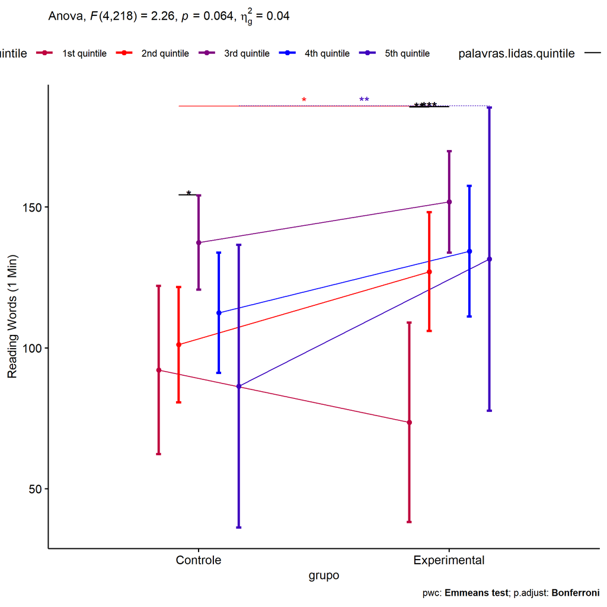

```r
if (length(unique(pdat[["palavras.lidas.quintile"]])) >= 2) {
  ggPlotAoC2(pwcs, "grupo", "palavras.lidas.quintile", aov, ylab = "Reading Words (1 Min)",
             subtitle = which(aov$Effect == "grupo:palavras.lidas.quintile"), addParam = "errorbar") +
    ggplot2::scale_color_manual(values = color[["palavras.lidas.quintile"]]) +
    ggplot2::ylab("Reading Words (1 Min)") +
    if (ymin.ci < ymax.ci) ggplot2::ylim(ymin.ci, ymax.ci)
}
```

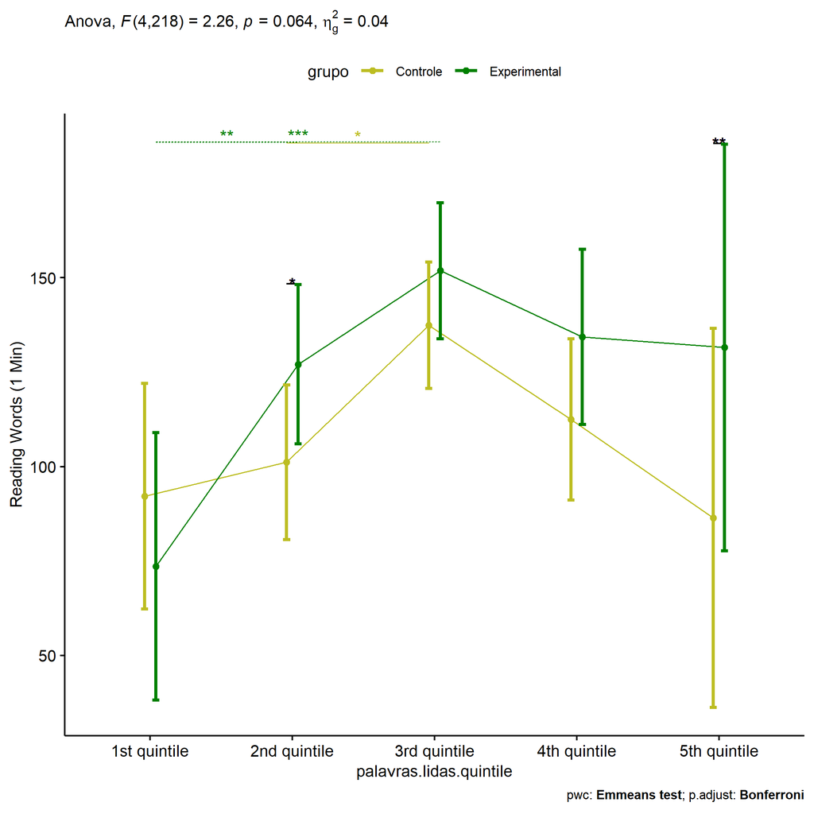

```r
if (length(unique(pdat[["palavras.lidas.quintile"]])) >= 2) {
  ggPlotAoC2(pwcs, "palavras.lidas.quintile", "grupo", aov, ylab = "Reading Words (1 Min)",
               subtitle = which(aov$Effect == "grupo:palavras.lidas.quintile"), addParam = "errorbar") +
    ggplot2::scale_color_manual(values = color[["grupo"]]) +
    ggplot2::ylab("Reading Words (1 Min)") +
    if (ymin.ci < ymax.ci) ggplot2::ylim(ymin.ci, ymax.ci)
}
```

```r
if (length(unique(pdat[["palavras.lidas.quintile"]])) >= 2) {
  plots <- twoWayAncovaBoxPlots(
    wdat, "palavras.lidas.pos", c("grupo","palavras.lidas.quintile"), aov, pwcs, covar = "palavras.lidas.pre",
    theme = "classic", color = color[["grupo:palavras.lidas.quintile"]],
    subtitle = which(aov$Effect == "grupo:palavras.lidas.quintile"))
}
```

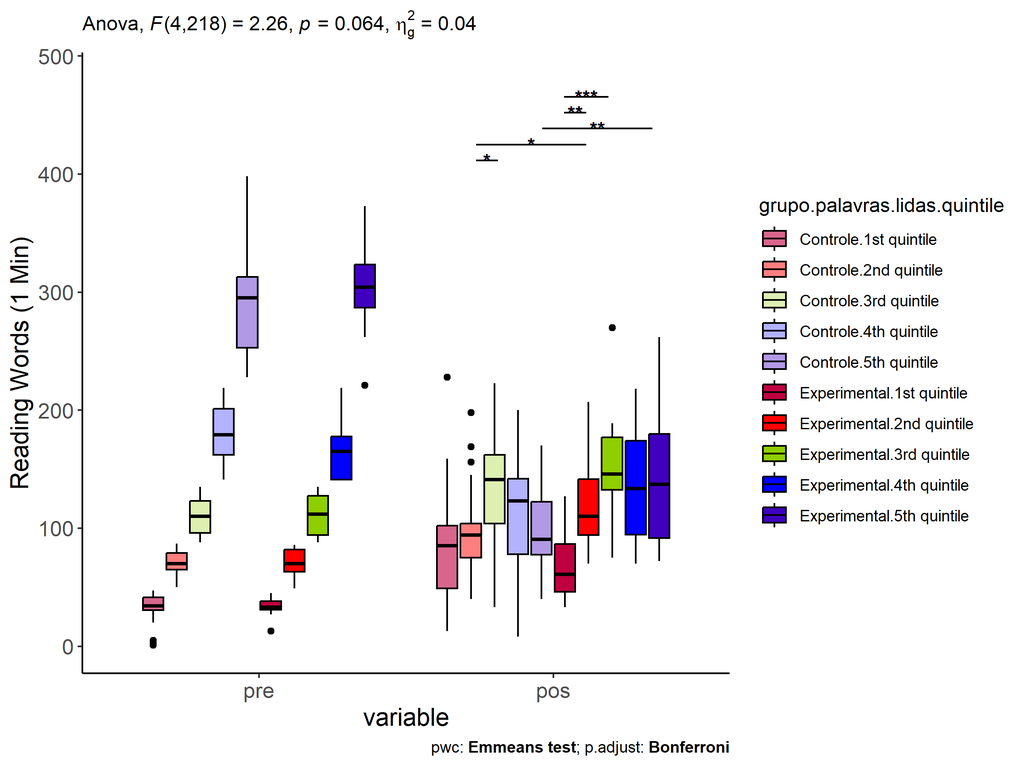

```r
if (length(unique(pdat[["palavras.lidas.quintile"]])) >= 2) {
  plots[["grupo:palavras.lidas.quintile"]] + ggplot2::ylab("Reading Words (1 Min)") +
  ggplot2::scale_x_discrete(labels=c('pre', 'pos')) +
  if (ymin < ymax) ggplot2::ylim(ymin, ymax)
}
```

```r
if (length(unique(pdat[["palavras.lidas.quintile"]])) >= 2) {
  plots <- twoWayAncovaBoxPlots(
    wdat.long, "palavras.lidas", c("grupo","palavras.lidas.quintile"), aov, pwc.long,
    pre.post = "time",
    theme = "classic", color = color$prepost)
}
```

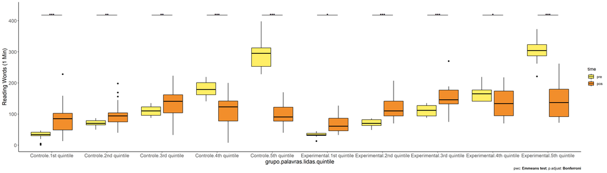

```r
if (length(unique(pdat[["palavras.lidas.quintile"]])) >= 2)
  plots[["grupo:palavras.lidas.quintile"]] + ggplot2::ylab("Reading Words (1 Min)") +
    if (ymin < ymax) ggplot2::ylim(ymin, ymax)
```

### Checking linearity assumption

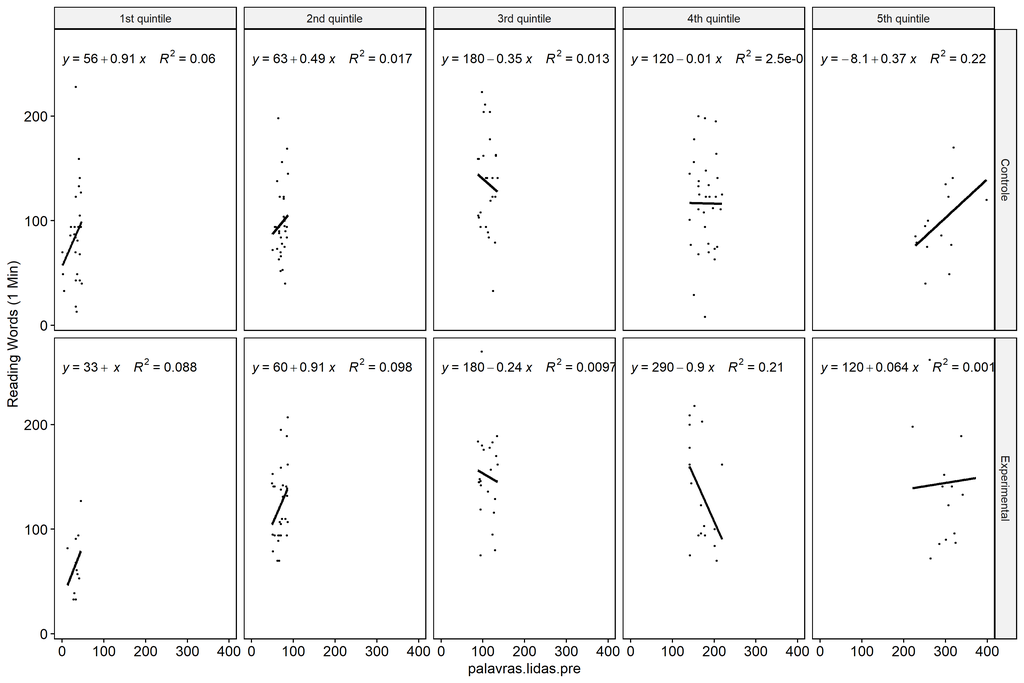

```r
if (length(unique(pdat[["palavras.lidas.quintile"]])) >= 2) {
  ggscatter(wdat, x = "palavras.lidas.pre", y = "palavras.lidas.pos", size = 0.5,
            facet.by = c("grupo","palavras.lidas.quintile"), add = "reg.line")+
    stat_regline_equation(
      aes(label =  paste(..eq.label.., ..rr.label.., sep = "~~~~"))
    ) + ggplot2::ylab("Reading Words (1 Min)") +
    if (ymin < ymax) ggplot2::ylim(ymin, ymax)
}
```

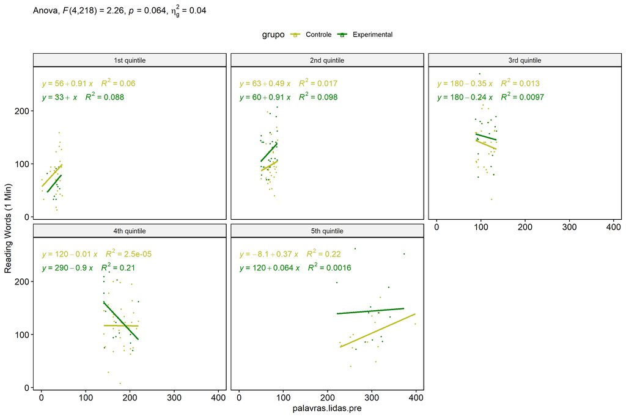

```r
if (length(unique(pdat[["palavras.lidas.quintile"]])) >= 2) {
  ggscatter(wdat, x = "palavras.lidas.pre", y = "palavras.lidas.pos", size = 0.5,
            color = "grupo", facet.by = "palavras.lidas.quintile", add = "reg.line")+
    stat_regline_equation(
      aes(label =  paste(..eq.label.., ..rr.label.., sep = "~~~~"), color = grupo)
    ) +
    ggplot2::labs(subtitle = rstatix::get_test_label(aov, detailed = T, row = which(aov$Effect == "grupo:palavras.lidas.quintile"))) +
    ggplot2::scale_color_manual(values = color[["grupo"]]) +
    ggplot2::ylab("Reading Words (1 Min)") +
    if (ymin < ymax) ggplot2::ylim(ymin, ymax)
}
```

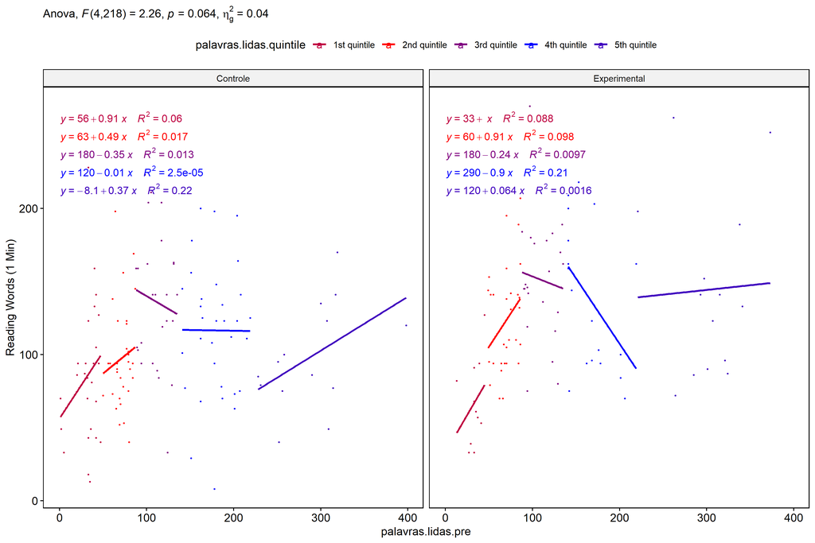

```r
if (length(unique(pdat[["palavras.lidas.quintile"]])) >= 2) {
  ggscatter(wdat, x = "palavras.lidas.pre", y = "palavras.lidas.pos", size = 0.5,
            color = "palavras.lidas.quintile", facet.by = "grupo", add = "reg.line")+
    stat_regline_equation(
      aes(label =  paste(..eq.label.., ..rr.label.., sep = "~~~~"), color = palavras.lidas.quintile)
    ) +
    ggplot2::labs(subtitle = rstatix::get_test_label(aov, detailed = T, row = which(aov$Effect == "grupo:palavras.lidas.quintile"))) +
    ggplot2::scale_color_manual(values = color[["palavras.lidas.quintile"]]) +
    ggplot2::ylab("Reading Words (1 Min)") +
    if (ymin < ymax) ggplot2::ylim(ymin, ymax)
}
```

### Checking normality and homogeneity

```r
if (length(unique(pdat[["palavras.lidas.quintile"]])) >= 2)
  res <- augment(lm(palavras.lidas.pos ~ palavras.lidas.pre + grupo*palavras.lidas.quintile, data = wdat))
```

```r
if (length(unique(pdat[["palavras.lidas.quintile"]])) >= 2)
  shapiro_test(res$.resid)
```

```
## # A tibble: 1 × 3
##   variable   statistic p.value
##   <chr>          <dbl>   <dbl>
## 1 res$.resid     0.985  0.0137
```

```r
if (length(unique(pdat[["palavras.lidas.quintile"]])) >= 2)
  levene_test(res, .resid ~ grupo*palavras.lidas.quintile)
```

```
## # A tibble: 1 × 4
##     df1   df2 statistic     p
##   <int> <int>     <dbl> <dbl>
## 1     9   219      1.64 0.105
```

# Summary of Results

## Descriptive Statistics

```r
df <- get.descriptives(ldat[["grupo"]], c(dv.pre, dv.pos), c("grupo"),
                       include.global = T, symmetry.test = T, normality.test = F)
df <- plyr::rbind.fill(
  df, do.call(plyr::rbind.fill, lapply(lfatores2, FUN = function(f) {
    if (nrow(dat) > 0 && sum(!is.na(unique(dat[[f]]))) > 1 && paste0("grupo:",f) %in% names(ldat))
      get.descriptives(ldat[[paste0("grupo:",f)]], c(dv.pre,dv.pos), c("grupo", f),
                       symmetry.test = T, normality.test = F)
    }))
)
df <- df[,c(fatores1[fatores1 %in% colnames(df)],"variable",
             colnames(df)[!colnames(df) %in% c(fatores1,"variable")])]
```

| grupo | genero | zona.participante | zona.escola | palavras.lidas.quintile | variable | n | mean | median | min | max | sd | se | ci | iqr | symmetry | skewness | kurtosis |
| --- | --- | --- | --- | --- | --- | --- | --- | --- | --- | --- | --- | --- | --- | --- | --- | --- | --- |
| Controle |  |  |  |  | palavras.lidas.pre | 131 | 121.626 | 98.0 | 1 | 398 | 80.785 | 7.058 | 13.964 | 112.00 | NO | 0.961 | 0.453 |
| Experimental |  |  |  |  | palavras.lidas.pre | 95 | 128.147 | 94.0 | 13 | 373 | 86.241 | 8.848 | 17.568 | 87.50 | NO | 1.162 | 0.422 |
|  |  |  |  |  | palavras.lidas.pre | 226 | 124.367 | 94.5 | 1 | 398 | 82.996 | 5.521 | 10.879 | 101.00 | NO | 1.069 | 0.515 |
| Controle |  |  |  |  | palavras.lidas.pos | 131 | 108.237 | 100.0 | 8 | 223 | 45.173 | 3.947 | 7.808 | 61.50 | YES | 0.353 | -0.152 |
| Experimental |  |  |  |  | palavras.lidas.pos | 95 | 128.653 | 131.0 | 33 | 262 | 46.727 | 4.794 | 9.519 | 65.00 | YES | 0.394 | -0.260 |
|  |  |  |  |  | palavras.lidas.pos | 226 | 116.819 | 109.0 | 8 | 262 | 46.832 | 3.115 | 6.139 | 60.75 | YES | 0.371 | -0.129 |
| Controle | F |  |  |  | palavras.lidas.pre | 13 | 121.538 | 117.0 | 61 | 204 | 42.896 | 11.897 | 25.922 | 61.00 | YES | 0.386 | -1.137 |
| Controle | M |  |  |  | palavras.lidas.pre | 8 | 126.500 | 97.5 | 40 | 293 | 86.802 | 30.689 | 72.568 | 91.00 | NO | 0.713 | -0.976 |
| Experimental | F |  |  |  | palavras.lidas.pre | 7 | 156.571 | 141.0 | 84 | 373 | 101.861 | 38.500 | 94.206 | 75.00 | NO | 1.227 | 0.011 |
| Experimental | M |  |  |  | palavras.lidas.pre | 13 | 127.692 | 123.0 | 49 | 338 | 78.893 | 21.881 | 47.674 | 71.00 | NO | 1.361 | 1.234 |
| Controle | F |  |  |  | palavras.lidas.pos | 13 | 165.692 | 162.0 | 138 | 200 | 20.926 | 5.804 | 12.645 | 22.00 | YES | 0.466 | -1.258 |
| Controle | M |  |  |  | palavras.lidas.pos | 8 | 166.250 | 161.5 | 141 | 219 | 24.824 | 8.776 | 20.753 | 16.75 | NO | 0.943 | -0.175 |
| Experimental | F |  |  |  | palavras.lidas.pos | 7 | 208.857 | 207.0 | 184 | 252 | 22.342 | 8.444 | 20.662 | 17.50 | NO | 0.739 | -0.701 |
| Experimental | M |  |  |  | palavras.lidas.pos | 13 | 176.000 | 178.0 | 144 | 200 | 18.362 | 5.093 | 11.096 | 27.00 | YES | -0.239 | -1.481 |
| Controle |  | Rural |  |  | palavras.lidas.pre | 47 | 124.404 | 102.0 | 29 | 319 | 79.055 | 11.531 | 23.211 | 105.50 | NO | 0.858 | -0.210 |
| Controle |  | Urbana |  |  | palavras.lidas.pre | 57 | 131.737 | 107.0 | 2 | 398 | 89.550 | 11.861 | 23.761 | 123.00 | NO | 0.884 | 0.091 |
| Experimental |  | Rural |  |  | palavras.lidas.pre | 42 | 125.476 | 89.5 | 27 | 341 | 92.595 | 14.288 | 28.855 | 87.50 | NO | 1.103 | -0.131 |
| Experimental |  | Urbana |  |  | palavras.lidas.pre | 32 | 150.656 | 133.0 | 50 | 373 | 91.875 | 16.241 | 33.125 | 109.25 | NO | 0.936 | -0.327 |
| Controle |  | Rural |  |  | palavras.lidas.pos | 47 | 116.553 | 112.0 | 18 | 228 | 48.159 | 7.025 | 14.140 | 53.00 | YES | 0.223 | -0.358 |
| Controle |  | Urbana |  |  | palavras.lidas.pos | 57 | 97.035 | 90.0 | 8 | 219 | 42.173 | 5.586 | 11.190 | 50.00 | YES | 0.487 | 0.337 |
| Experimental |  | Rural |  |  | palavras.lidas.pos | 42 | 115.238 | 114.5 | 33 | 218 | 42.315 | 6.529 | 13.186 | 58.00 | YES | 0.167 | -0.449 |
| Experimental |  | Urbana |  |  | palavras.lidas.pos | 32 | 147.312 | 141.0 | 70 | 262 | 53.587 | 9.473 | 19.320 | 94.25 | YES | 0.471 | -0.748 |
| Controle |  |  | Rural |  | palavras.lidas.pre | 51 | 163.059 | 175.0 | 5 | 398 | 95.514 | 13.375 | 26.864 | 139.50 | YES | 0.330 | -0.818 |
| Controle |  |  | Urbana |  | palavras.lidas.pre | 81 | 97.617 | 79.0 | 1 | 293 | 60.413 | 6.713 | 13.358 | 77.00 | NO | 0.897 | 0.402 |
| Experimental |  |  | Rural |  | palavras.lidas.pre | 36 | 143.750 | 117.5 | 13 | 341 | 103.202 | 17.200 | 34.918 | 136.00 | NO | 0.598 | -1.081 |
| Experimental |  |  | Urbana |  | palavras.lidas.pre | 59 | 118.729 | 94.0 | 29 | 373 | 73.246 | 9.536 | 19.088 | 71.00 | NO | 1.663 | 2.528 |
| Controle |  |  | Rural |  | palavras.lidas.pos | 51 | 101.863 | 100.0 | 8 | 211 | 43.380 | 6.074 | 12.201 | 62.00 | YES | 0.077 | -0.394 |
| Controle |  |  | Urbana |  | palavras.lidas.pos | 81 | 112.185 | 100.0 | 13 | 262 | 48.496 | 5.388 | 10.723 | 60.00 | NO | 0.667 | 0.308 |
| Experimental |  |  | Rural |  | palavras.lidas.pos | 36 | 104.000 | 94.5 | 33 | 178 | 34.420 | 5.737 | 11.646 | 39.00 | YES | 0.320 | -0.587 |
| Experimental |  |  | Urbana |  | palavras.lidas.pos | 59 | 143.695 | 142.0 | 39 | 262 | 47.078 | 6.129 | 12.269 | 70.50 | YES | 0.155 | -0.358 |
| Controle |  |  |  | 1st quintile | palavras.lidas.pre | 26 | 32.154 | 34.0 | 1 | 47 | 12.746 | 2.500 | 5.148 | 11.00 | NO | -1.265 | 0.645 |
| Controle |  |  |  | 2nd quintile | palavras.lidas.pre | 33 | 71.273 | 70.0 | 50 | 87 | 9.187 | 1.599 | 3.257 | 14.00 | YES | -0.212 | -0.825 |
| Controle |  |  |  | 3rd quintile | palavras.lidas.pre | 27 | 110.111 | 110.0 | 88 | 135 | 14.947 | 2.877 | 5.913 | 27.00 | YES | 0.046 | -1.405 |
| Controle |  |  |  | 4th quintile | palavras.lidas.pre | 32 | 179.188 | 179.0 | 141 | 219 | 22.777 | 4.026 | 8.212 | 39.00 | YES | -0.045 | -1.225 |
| Controle |  |  |  | 5th quintile | palavras.lidas.pre | 14 | 287.857 | 295.0 | 228 | 398 | 45.544 | 12.172 | 26.297 | 59.75 | NO | 0.661 | -0.041 |
| Experimental |  |  |  | 1st quintile | palavras.lidas.pre | 11 | 33.182 | 33.0 | 13 | 45 | 8.460 | 2.551 | 5.683 | 7.00 | NO | -0.922 | 0.413 |
| Experimental |  |  |  | 2nd quintile | palavras.lidas.pre | 31 | 69.548 | 70.0 | 49 | 86 | 12.239 | 2.198 | 4.489 | 19.00 | YES | -0.199 | -1.201 |
| Experimental |  |  |  | 3rd quintile | palavras.lidas.pre | 23 | 110.696 | 112.0 | 88 | 135 | 17.293 | 3.606 | 7.478 | 33.50 | YES | 0.086 | -1.780 |
| Experimental |  |  |  | 4th quintile | palavras.lidas.pre | 18 | 166.389 | 165.0 | 141 | 219 | 25.964 | 6.120 | 12.912 | 36.25 | NO | 0.586 | -1.082 |
| Experimental |  |  |  | 5th quintile | palavras.lidas.pre | 14 | 303.000 | 304.0 | 221 | 373 | 38.113 | 10.186 | 22.006 | 36.25 | YES | -0.295 | -0.347 |
| Controle |  |  |  | 1st quintile | palavras.lidas.pos | 26 | 85.615 | 85.0 | 13 | 228 | 47.569 | 9.329 | 19.214 | 53.25 | NO | 0.890 | 0.986 |
| Controle |  |  |  | 2nd quintile | palavras.lidas.pos | 33 | 97.424 | 94.0 | 40 | 198 | 34.251 | 5.962 | 12.145 | 29.00 | NO | 0.971 | 0.800 |
| Controle |  |  |  | 3rd quintile | palavras.lidas.pos | 27 | 136.481 | 141.0 | 33 | 223 | 45.249 | 8.708 | 17.900 | 58.00 | YES | 0.008 | -0.517 |
| Controle |  |  |  | 4th quintile | palavras.lidas.pos | 32 | 116.469 | 123.0 | 8 | 200 | 45.950 | 8.123 | 16.567 | 64.25 | YES | -0.160 | -0.322 |
| Controle |  |  |  | 5th quintile | palavras.lidas.pos | 14 | 98.214 | 90.5 | 40 | 170 | 36.090 | 9.645 | 20.838 | 44.75 | YES | 0.264 | -0.879 |
| Experimental |  |  |  | 1st quintile | palavras.lidas.pos | 11 | 67.091 | 61.0 | 33 | 127 | 29.256 | 8.821 | 19.654 | 40.50 | NO | 0.530 | -0.871 |
| Experimental |  |  |  | 2nd quintile | palavras.lidas.pos | 31 | 123.226 | 110.0 | 70 | 207 | 35.789 | 6.428 | 13.127 | 47.50 | NO | 0.559 | -0.513 |
| Experimental |  |  |  | 3rd quintile | palavras.lidas.pos | 23 | 150.913 | 146.0 | 75 | 270 | 41.316 | 8.615 | 17.866 | 44.50 | NO | 0.507 | 1.154 |
| Experimental |  |  |  | 4th quintile | palavras.lidas.pos | 18 | 137.444 | 133.5 | 70 | 218 | 50.160 | 11.823 | 24.944 | 79.50 | YES | 0.215 | -1.567 |
| Experimental |  |  |  | 5th quintile | palavras.lidas.pos | 14 | 144.429 | 137.0 | 72 | 262 | 60.883 | 16.272 | 35.153 | 88.25 | NO | 0.651 | -0.912 |

## ANCOVA Table Comparison

```r
df <- do.call(plyr::rbind.fill, laov)
df <- df[!duplicated(df$Effect),]
```

|  | Effect | DFn | DFd | F | p | p<.05 | ges | DFn’ | DFd’ | F’ | p’ | p<.05’ | ges’ |
| --- | --- | --- | --- | --- | --- | --- | --- | --- | --- | --- | --- | --- | --- |
| 1 | grupo | 1 | 223 | 10.571 | 0.001 | * | 0.045 | 1 | 238 | 10.181 | 0.002 | * | 0.041 |
| 2 | palavras.lidas.pre | 1 | 223 | 13.569 | 0.000 | * | 0.057 | 1 | 238 | 9.375 | 0.002 | * | 0.038 |
| 3 | genero | 1 | 36 | 7.586 | 0.009 | * | 0.174 | 1 | 236 | 4.146 | 0.043 | * | 0.017 |
| 5 | grupo:genero | 1 | 36 | 7.757 | 0.008 | * | 0.177 | 1 | 236 | 4.356 | 0.038 | * | 0.018 |
| 8 | grupo:zona.participante | 1 | 173 | 12.836 | 0.000 | * | 0.069 | 1 | 182 | 5.791 | 0.017 | * | 0.031 |
| 10 | zona.participante | 1 | 173 | 0.002 | 0.964 |  | 0.000 | 1 | 182 | 2.204 | 0.139 |  | 0.012 |
| 12 | grupo:zona.escola | 1 | 222 | 3.501 | 0.063 |  | 0.016 | 1 | 236 | 3.863 | 0.051 |  | 0.016 |
| 14 | zona.escola | 1 | 222 | 26.182 | 0.000 | * | 0.105 | 1 | 236 | 30.186 | 0.000 | * | 0.113 |
| 16 | grupo:palavras.lidas.quintile | 4 | 218 | 2.261 | 0.064 |  | 0.040 | 4 | 230 | 2.270 | 0.063 |  | 0.038 |
| 18 | palavras.lidas.quintile | 4 | 218 | 8.898 | 0.000 | * | 0.140 | 4 | 230 | 4.624 | 0.001 | * | 0.074 |

## PairWise Table Comparison

```r
df <- do.call(plyr::rbind.fill, lpwc)
df <- df[,c(names(lfatores)[names(lfatores) %in% colnames(df)],
            names(df)[!names(df) %in% c(names(lfatores),"term",".y.")])]
```

| grupo | genero | zona.participante | zona.escola | palavras.lidas.quintile | group1 | group2 | df | statistic | p | p.adj | p.adj.signif | df’ | statistic’ | p’ | p.adj’ | p.adj.signif’ |
| --- | --- | --- | --- | --- | --- | --- | --- | --- | --- | --- | --- | --- | --- | --- | --- | --- |
| Controle |  |  |  |  | pre | pos | 448 | 1.615 | 0.107 | 0.107 | ns | 478 | 0.841 | 0.401 | 0.401 | ns |
| Experimental |  |  |  |  | pre | pos | 448 | -0.052 | 0.959 | 0.959 | ns | 478 | -1.454 | 0.146 | 0.146 | ns |
|  |  |  |  |  | Controle | Experimental | 223 | -3.251 | 0.001 | 0.001 | ** | 238 | -3.191 | 0.002 | 0.002 | ** |
| Controle | F |  |  |  | pre | pos | 74 | -2.026 | 0.046 | 0.046 | * | 474 | 0.612 | 0.541 | 0.541 | ns |
| Controle | M |  |  |  | pre | pos | 74 | -1.431 | 0.157 | 0.157 | ns | 474 | 0.585 | 0.559 | 0.559 | ns |
| Controle |  |  |  |  | F | M | 36 | 0.071 | 0.943 | 0.943 | ns | 236 | 0.170 | 0.865 | 0.865 | ns |
| Experimental | F |  |  |  | pre | pos | 74 | -1.761 | 0.082 | 0.082 | ns | 474 | -1.540 | 0.124 | 0.124 | ns |
| Experimental | M |  |  |  | pre | pos | 74 | -2.217 | 0.030 | 0.030 | * | 474 | -0.550 | 0.582 | 0.582 | ns |
| Experimental |  |  |  |  | F | M | 36 | 3.916 | 0.000 | 0.000 | *** | 236 | 2.911 | 0.004 | 0.004 | ** |
|  | F |  |  |  | Controle | Experimental | 36 | -5.210 | 0.000 | 0.000 | **** | 236 | -3.838 | 0.000 | 0.000 | *** |
|  | M |  |  |  | Controle | Experimental | 36 | -1.456 | 0.154 | 0.154 | ns | 236 | -0.873 | 0.384 | 0.384 | ns |
| Controle |  |  |  |  | Rural | Urbana | 173 | 2.260 | 0.025 | 0.025 | * | 182 | 0.434 | 0.665 | 0.665 | ns |
| Controle |  | Rural |  |  | pre | pos | 348 | 0.542 | 0.588 | 0.588 | ns | 366 | 0.496 | 0.620 | 0.620 | ns |
| Controle |  | Urbana |  |  | pre | pos | 348 | 2.636 | 0.009 | 0.009 | ** | 366 | 1.467 | 0.143 | 0.143 | ns |
| Experimental |  |  |  |  | Rural | Urbana | 173 | -2.774 | 0.006 | 0.006 | ** | 182 | -2.793 | 0.006 | 0.006 | ** |
| Experimental |  | Rural |  |  | pre | pos | 348 | 0.668 | 0.505 | 0.505 | ns | 366 | 0.361 | 0.718 | 0.718 | ns |
| Experimental |  | Urbana |  |  | pre | pos | 348 | 0.190 | 0.849 | 0.849 | ns | 366 | -0.847 | 0.397 | 0.397 | ns |
|  |  | Rural |  |  | Controle | Experimental | 173 | 0.147 | 0.883 | 0.883 | ns | 182 | -0.167 | 0.868 | 0.868 | ns |
|  |  | Urbana |  |  | Controle | Experimental | 173 | -4.821 | 0.000 | 0.000 | **** | 182 | -3.575 | 0.000 | 0.000 | *** |
| Controle |  |  |  |  | Rural | Urbana | 222 | -2.684 | 0.008 | 0.008 | ** | 236 | -2.890 | 0.004 | 0.004 | ** |
| Controle |  |  | Rural |  | pre | pos | 446 | 4.754 | 0.000 | 0.000 | **** | 474 | 4.169 | 0.000 | 0.000 | **** |
| Controle |  |  | Urbana |  | pre | pos | 446 | -1.426 | 0.154 | 0.154 | ns | 474 | -2.147 | 0.032 | 0.032 | * |
| Experimental |  |  |  |  | Rural | Urbana | 222 | -4.817 | 0.000 | 0.000 | **** | 236 | -5.150 | 0.000 | 0.000 | **** |
| Experimental |  |  | Rural |  | pre | pos | 446 | 2.595 | 0.010 | 0.010 | ** | 474 | 2.363 | 0.019 | 0.019 | * |
| Experimental |  |  | Urbana |  | pre | pos | 446 | -2.086 | 0.038 | 0.038 | * | 474 | -3.597 | 0.000 | 0.000 | *** |
|  |  |  | Rural |  | Controle | Experimental | 222 | -0.581 | 0.562 | 0.562 | ns | 236 | -0.318 | 0.751 | 0.751 | ns |
|  |  |  | Urbana |  | Controle | Experimental | 222 | -3.771 | 0.000 | 0.000 | *** | 236 | -3.702 | 0.000 | 0.000 | *** |
| Controle |  |  |  | 1st quintile | pre | pos | 438 | -5.688 | 0.000 | 0.000 | **** | 462 | -4.205 | 0.000 | 0.000 | **** |
| Controle |  |  |  | 2nd quintile | pre | pos | 438 | -3.135 | 0.002 | 0.002 | ** | 462 | -3.058 | 0.002 | 0.002 | ** |
| Controle |  |  |  | 3rd quintile | pre | pos | 438 | -2.859 | 0.004 | 0.004 | ** | 462 | -2.536 | 0.012 | 0.012 | * |
| Controle |  |  |  | 4th quintile | pre | pos | 438 | 7.403 | 0.000 | 0.000 | **** | 462 | 4.742 | 0.000 | 0.000 | **** |
| Controle |  |  |  | 5th quintile | pre | pos | 438 | 14.806 | 0.000 | 0.000 | **** | 462 | 10.362 | 0.000 | 0.000 | **** |
| Controle |  |  |  |  | 1st quintile | 2nd quintile | 218 | -0.719 | 0.473 | 1.000 | ns | 230 | -1.561 | 0.120 | 1.000 | ns |
| Controle |  |  |  |  | 1st quintile | 3rd quintile | 218 | -2.831 | 0.005 | 0.051 | ns | 230 | -3.183 | 0.002 | 0.017 | * |
| Controle |  |  |  |  | 1st quintile | 4th quintile | 218 | -0.873 | 0.383 | 1.000 | ns | 230 | -2.177 | 0.030 | 0.305 | ns |
| Controle |  |  |  |  | 1st quintile | 5th quintile | 218 | 0.152 | 0.880 | 1.000 | ns | 230 | -1.573 | 0.117 | 1.000 | ns |
| Controle |  |  |  |  | 2nd quintile | 3rd quintile | 218 | -2.926 | 0.004 | 0.038 | * | 230 | -2.501 | 0.013 | 0.131 | ns |
| Controle |  |  |  |  | 2nd quintile | 4th quintile | 218 | -0.617 | 0.538 | 1.000 | ns | 230 | -1.675 | 0.095 | 0.954 | ns |
| Controle |  |  |  |  | 2nd quintile | 5th quintile | 218 | 0.449 | 0.654 | 1.000 | ns | 230 | -1.205 | 0.229 | 1.000 | ns |
| Controle |  |  |  |  | 3rd quintile | 4th quintile | 218 | 1.694 | 0.092 | 0.917 | ns | 230 | 0.035 | 0.972 | 1.000 | ns |
| Controle |  |  |  |  | 3rd quintile | 5th quintile | 218 | 1.803 | 0.073 | 0.728 | ns | 230 | -0.266 | 0.790 | 1.000 | ns |
| Controle |  |  |  |  | 4th quintile | 5th quintile | 218 | 1.279 | 0.202 | 1.000 | ns | 230 | -0.400 | 0.690 | 1.000 | ns |
| Experimental |  |  |  | 1st quintile | pre | pos | 438 | -2.347 | 0.019 | 0.019 | * | 462 | -1.735 | 0.083 | 0.083 | ns |
| Experimental |  |  |  | 2nd quintile | pre | pos | 438 | -6.236 | 0.000 | 0.000 | **** | 462 | -6.542 | 0.000 | 0.000 | **** |
| Experimental |  |  |  | 3rd quintile | pre | pos | 438 | -4.025 | 0.000 | 0.000 | **** | 462 | -3.451 | 0.001 | 0.001 | *** |
| Experimental |  |  |  | 4th quintile | pre | pos | 438 | 2.562 | 0.011 | 0.011 | * | 462 | 1.894 | 0.059 | 0.059 | ns |
| Experimental |  |  |  | 5th quintile | pre | pos | 438 | 12.380 | 0.000 | 0.000 | **** | 462 | 7.308 | 0.000 | 0.000 | **** |
| Experimental |  |  |  |  | 1st quintile | 2nd quintile | 218 | -3.360 | 0.001 | 0.009 | ** | 230 | -3.686 | 0.000 | 0.003 | ** |
| Experimental |  |  |  |  | 1st quintile | 3rd quintile | 218 | -4.104 | 0.000 | 0.001 | *** | 230 | -3.909 | 0.000 | 0.001 | ** |
| Experimental |  |  |  |  | 1st quintile | 4th quintile | 218 | -2.463 | 0.015 | 0.145 | ns | 230 | -2.826 | 0.005 | 0.051 | ns |
| Experimental |  |  |  |  | 1st quintile | 5th quintile | 218 | -1.412 | 0.159 | 1.000 | ns | 230 | -2.989 | 0.003 | 0.031 | * |
| Experimental |  |  |  |  | 2nd quintile | 3rd quintile | 218 | -1.882 | 0.061 | 0.612 | ns | 230 | -1.215 | 0.226 | 1.000 | ns |
| Experimental |  |  |  |  | 2nd quintile | 4th quintile | 218 | -0.393 | 0.695 | 1.000 | ns | 230 | -0.585 | 0.559 | 1.000 | ns |
| Experimental |  |  |  |  | 2nd quintile | 5th quintile | 218 | -0.127 | 0.899 | 1.000 | ns | 230 | -1.780 | 0.076 | 0.764 | ns |
| Experimental |  |  |  |  | 3rd quintile | 4th quintile | 218 | 1.121 | 0.263 | 1.000 | ns | 230 | 0.314 | 0.754 | 1.000 | ns |
| Experimental |  |  |  |  | 3rd quintile | 5th quintile | 218 | 0.671 | 0.503 | 1.000 | ns | 230 | -1.515 | 0.131 | 1.000 | ns |
| Experimental |  |  |  |  | 4th quintile | 5th quintile | 218 | 0.116 | 0.907 | 1.000 | ns | 230 | -2.101 | 0.037 | 0.367 | ns |
|  |  |  |  | 1st quintile | Controle | Experimental | 218 | 1.200 | 0.231 | 0.231 | ns | 230 | 0.833 | 0.406 | 0.406 | ns |
|  |  |  |  | 2nd quintile | Controle | Experimental | 218 | -2.405 | 0.017 | 0.017 | * | 230 | -2.465 | 0.014 | 0.014 | * |
|  |  |  |  | 3rd quintile | Controle | Experimental | 218 | -1.177 | 0.241 | 0.241 | ns | 230 | -0.882 | 0.379 | 0.379 | ns |
|  |  |  |  | 4th quintile | Controle | Experimental | 218 | -1.708 | 0.089 | 0.089 | ns | 230 | -0.490 | 0.624 | 0.624 | ns |
|  |  |  |  | 5th quintile | Controle | Experimental | 218 | -2.748 | 0.006 | 0.006 | ** | 230 | -3.039 | 0.003 | 0.003 | ** |

## EMMS Table Comparison

```r
df <- do.call(plyr::rbind.fill, lemms)
df[["N-N'"]] <- df[["N"]] - df[["N'"]]
df <- df[,c(names(lfatores)[names(lfatores) %in% colnames(df)],
            names(df)[!names(df) %in% names(lfatores)])]
```

| grupo | genero | zona.participante | zona.escola | palavras.lidas.quintile | N | M (pre) | SE (pre) | M (unadj) | SE (unadj) | M (adj) | SE (adj) | conf.low | conf.high | N’ | M (pre)’ | SE (pre)’ | M (unadj)’ | SE (unadj)’ | M (adj)’ | SE (adj)’ | conf.low’ | conf.high’ | N-N’ |
| --- | --- | --- | --- | --- | --- | --- | --- | --- | --- | --- | --- | --- | --- | --- | --- | --- | --- | --- | --- | --- | --- | --- | --- |
| Controle |  |  |  |  | 131 | 121.626 | 7.058 | 108.237 | 3.947 | 108.599 | 3.898 | 100.918 | 116.280 | 137 | 122.562 | 6.914 | 114.993 | 5.132 | 115.288 | 5.438 | 104.576 | 126.001 | -6 |
| Experimental |  |  |  |  | 95 | 128.147 | 8.848 | 128.653 | 4.794 | 128.153 | 4.578 | 119.133 | 137.174 | 104 | 127.077 | 8.412 | 142.096 | 6.907 | 141.707 | 6.242 | 129.411 | 154.002 | -9 |
| Controle | F |  |  |  | 13 | 121.538 | 11.897 | 165.692 | 5.804 | 167.529 | 4.037 | 159.341 | 175.717 | 73 | 123.466 | 9.683 | 115.973 | 5.528 | 116.117 | 7.349 | 101.639 | 130.594 | -60 |
| Controle | M |  |  |  | 8 | 126.500 | 30.689 | 166.250 | 8.776 | 167.063 | 5.136 | 156.647 | 177.478 | 64 | 121.531 | 9.934 | 113.875 | 9.047 | 114.286 | 7.850 | 98.821 | 129.750 | -56 |
| Experimental | F |  |  |  | 7 | 156.571 | 38.500 | 208.857 | 8.444 | 203.464 | 5.550 | 192.208 | 214.721 | 50 | 139.780 | 12.443 | 162.560 | 10.682 | 160.456 | 8.911 | 142.901 | 178.011 | -43 |
| Experimental | M |  |  |  | 13 | 127.692 | 21.881 | 176.000 | 5.093 | 176.567 | 4.028 | 168.397 | 184.737 | 54 | 115.315 | 11.262 | 123.148 | 8.173 | 124.415 | 8.556 | 107.559 | 141.271 | -41 |
| Controle |  | Rural |  |  | 47 | 124.404 | 11.531 | 116.553 | 7.025 | 117.253 | 6.627 | 104.173 | 130.332 | 47 | 124.404 | 11.531 | 116.553 | 7.025 | 117.323 | 9.274 | 99.023 | 135.622 | 0 |
| Controle |  | Urbana |  |  | 57 | 131.737 | 11.861 | 97.035 | 5.586 | 97.034 | 6.012 | 85.168 | 108.900 | 61 | 132.492 | 11.276 | 112.098 | 9.330 | 111.967 | 8.135 | 95.916 | 128.017 | -4 |
| Experimental |  | Rural |  |  | 42 | 125.476 | 14.288 | 115.238 | 6.529 | 115.835 | 7.008 | 102.004 | 129.667 | 43 | 124.814 | 13.967 | 118.837 | 7.321 | 119.561 | 9.695 | 100.432 | 138.689 | -1 |
| Experimental |  | Urbana |  |  | 32 | 150.656 | 16.241 | 147.312 | 9.473 | 145.503 | 8.058 | 129.600 | 161.407 | 36 | 146.083 | 15.431 | 161.417 | 13.509 | 159.771 | 10.618 | 138.820 | 180.721 | -4 |
| Controle |  |  | Rural |  | 51 | 163.059 | 13.375 | 101.863 | 6.074 | 95.348 | 6.170 | 83.189 | 107.508 | 52 | 162.173 | 13.145 | 103.827 | 6.272 | 95.746 | 8.486 | 79.029 | 112.464 | -1 |
| Controle |  |  | Urbana |  | 81 | 97.617 | 6.713 | 112.185 | 5.388 | 116.909 | 4.876 | 107.299 | 126.518 | 85 | 98.329 | 6.493 | 121.824 | 7.257 | 127.441 | 6.605 | 114.429 | 140.452 | -4 |
| Experimental |  |  | Rural |  | 36 | 143.750 | 17.200 | 104.000 | 5.737 | 100.801 | 7.194 | 86.624 | 114.979 | 36 | 143.750 | 17.200 | 104.000 | 5.737 | 99.872 | 10.001 | 80.169 | 119.575 | 0 |
| Experimental |  |  | Urbana |  | 59 | 118.729 | 9.536 | 143.695 | 6.129 | 144.793 | 5.600 | 133.757 | 155.829 | 68 | 118.250 | 9.010 | 162.265 | 9.248 | 163.608 | 7.251 | 149.322 | 177.893 | -9 |
| Controle |  |  |  | 1st quintile | 26 | 32.154 | 2.500 | 85.615 | 9.329 | 92.160 | 15.136 | 62.329 | 121.991 | 26 | 32.154 | 2.500 | 85.615 | 9.329 | 67.234 | 21.101 | 25.659 | 108.809 | 0 |
| Controle |  |  |  | 2nd quintile | 33 | 71.273 | 1.599 | 97.424 | 5.962 | 101.159 | 10.374 | 80.714 | 121.604 | 34 | 71.235 | 1.552 | 105.235 | 9.720 | 94.632 | 14.502 | 66.057 | 123.207 | -1 |
| Controle |  |  |  | 3rd quintile | 27 | 110.111 | 2.877 | 136.481 | 8.708 | 137.427 | 8.488 | 120.697 | 154.156 | 28 | 109.536 | 2.831 | 140.607 | 9.351 | 137.627 | 11.898 | 114.184 | 161.070 | -1 |
| Controle |  |  |  | 4th quintile | 32 | 179.188 | 4.026 | 116.469 | 8.123 | 112.452 | 10.835 | 91.097 | 133.807 | 33 | 179.485 | 3.914 | 125.970 | 12.339 | 136.911 | 14.838 | 107.676 | 166.146 | -1 |
| Controle |  |  |  | 5th quintile | 14 | 287.857 | 12.172 | 98.214 | 9.645 | 86.393 | 25.438 | 36.257 | 136.528 | 16 | 283.938 | 11.429 | 116.000 | 14.901 | 147.730 | 33.641 | 81.446 | 214.015 | -2 |
| Experimental |  |  |  | 1st quintile | 11 | 33.182 | 2.551 | 67.091 | 8.821 | 73.562 | 17.970 | 38.145 | 108.979 | 11 | 33.182 | 2.551 | 67.091 | 8.821 | 48.914 | 25.196 | -0.730 | 98.558 | 0 |
| Experimental |  |  |  | 2nd quintile | 31 | 69.548 | 2.198 | 123.226 | 6.428 | 127.084 | 10.710 | 105.976 | 148.193 | 35 | 70.086 | 1.972 | 141.771 | 10.687 | 130.939 | 14.545 | 102.281 | 159.597 | -4 |
| Experimental |  |  |  | 3rd quintile | 23 | 110.696 | 3.606 | 150.913 | 8.615 | 151.816 | 9.150 | 133.783 | 169.850 | 24 | 109.875 | 3.548 | 155.542 | 9.458 | 152.629 | 12.786 | 127.436 | 177.822 | -1 |
| Experimental |  |  |  | 4th quintile | 18 | 166.389 | 6.120 | 137.444 | 11.823 | 134.347 | 11.767 | 111.157 | 157.538 | 18 | 166.389 | 6.120 | 137.444 | 11.823 | 145.779 | 16.427 | 113.413 | 178.146 | 0 |
| Experimental |  |  |  | 5th quintile | 14 | 303.000 | 10.186 | 144.429 | 16.272 | 131.519 | 27.315 | 77.684 | 185.355 | 16 | 297.875 | 9.536 | 179.438 | 27.803 | 213.942 | 35.994 | 143.021 | 284.862 | -2 |